# Data wrangling with tidy

Rockefeller University, Bioinformatics Resource Centre

https://rockefelleruniversity.github.io/RU_tidyverse/

# Data wrangling with Tidy

**Some problems we face when dealing with data regularly.**

- Every dataset is different. Sometimes very different.
- There are many ways to do things. Everyone has their favorite syntax.

**The issue:** Many fundamental data processing functions exist in *Base R* and beyond. Sometimes they can be inconsistent or unnecessarily complex. Especially when dealing with non-standard dataframes. The result is code that is confusing and doesn’t flow i.e. nested functions

## What does it mean to be tidy?

Tidyverse is most importantly a philosophy for data analysis that more often then not makes wrangling data easier. The tidyverse community have built what they describe as an *opinionated* group of packages. These packages readily talk to one another.

- More efficient code
- Easier to remember syntax
- Easier to read syntax

You can read their [manifesto](https://cran.r-project.org/web/packages/tidyverse/vignettes/manifesto.html) to get a better understanding of the tidy ethos.

## What does it *actually* mean to be tidy?

- A defined vision for coding style in R
- A defined vision for data formats in R
- A defined vision for package design in R
- Unified set of community pushing in a cohesive direction
- Critical mass of people to influence the way the whole R community evolves

## What are the main tidy tools?

- ggplot2 – making pretty graphs
- readr – reading data into R
- dplyr – manipulating data
- tibble - working with tibbles
- tidyr – miscellaneous tools for tidying data
- purrr - iterating over data
- stringr – working with strings
- forcats - working with factors

Other tools have now been made for the tidy community. This community also overlaps with bioconductor. But the packages above are the linchpins that hold it together.

## What we won’t be doing today

We already have a course online for plotting, including ggplot.

https://rockefelleruniversity.github.io/Plotting_In_R/

# Lets get tidy!

First step lets load in the data we are using today

```r
load(file='dataset/my_tidy.Rdata')
```

## Are all data frames equal?

```r
head(df1)
```

```
## # A tibble: 6 x 5
##   salmon_id common_name    age_classbylength  length_mm IGF1_ng_ml
##       <dbl> <chr>          <chr>                  <dbl>      <dbl>
## 1     35032 Chinook salmon yearling                 147       41.3
## 2     35035 Sockeye salmon juvenile                 121       NA
## 3     35036 Sockeye salmon juvenile                 112       NA
## 4     35037 Steelhead      juvenile                 220       42.7
## 5     35038 Steelhead      juvenile                 152       NA
## 6     35033 Chinook salmon mixed age juvenile       444       62.1
```

```r
head(df2)
```

```
## # A tibble: 6 x 5
##   salmon_id common_name    age_classbylength  variable   value
##       <dbl> <chr>          <chr>              <fct>      <dbl>
## 1     35032 Chinook salmon yearling           length_mm  147
## 2     35032 Chinook salmon yearling           IGF1_ng_ml  41.3
## 3     35033 Chinook salmon mixed age juvenile length_mm  444
## 4     35033 Chinook salmon mixed age juvenile IGF1_ng_ml  62.1
## 5     35034 Sockeye salmon juvenile           length_mm  139
## 6     35034 Sockeye salmon juvenile           IGF1_ng_ml  NA
```

## Are all data frames equal?

```r
head(df3a)
```

```
## # A tibble: 6 x 5
##   salmon_id common_name    age_classbylength  variable  value
##       <dbl> <chr>          <chr>              <fct>     <dbl>
## 1     35032 Chinook salmon yearling           length_mm   147
## 2     35033 Chinook salmon mixed age juvenile length_mm   444
## 3     35034 Sockeye salmon juvenile           length_mm   139
## 4     35035 Sockeye salmon juvenile           length_mm   121
## 5     35036 Sockeye salmon juvenile           length_mm   112
## 6     35037 Steelhead      juvenile           length_mm   220
```

```r
head(df3b)
```

```
## # A tibble: 6 x 5
##   salmon_id common_name    age_classbylength  variable   value
##       <dbl> <chr>          <chr>              <fct>      <dbl>
## 1     35032 Chinook salmon yearling           IGF1_ng_ml  41.3
## 2     35033 Chinook salmon mixed age juvenile IGF1_ng_ml  62.1
## 3     35034 Sockeye salmon juvenile           IGF1_ng_ml  NA
## 4     35035 Sockeye salmon juvenile           IGF1_ng_ml  NA
## 5     35036 Sockeye salmon juvenile           IGF1_ng_ml  NA
## 6     35037 Steelhead      juvenile           IGF1_ng_ml  42.7
```

## What is a tidy dataset?

A tidy dataset is a data frame (or table) for which the following are true:

- Each variable has its own column
- Each observation has its own row
- Each value has its own cell

## *Which of our dataframes is tidy?*

Our first dataframe is tidy

## Why bother?

Consistent dataframe layouts help to ensure that all values are present and that relationships between data points are clear.

R is a vectorized programming language. R builds data frames from vectors, and R works best when its operation are vectorized. Tidy data utilizes of both of these aspects of R.

=> Precise and Fast

## Lets load in the tidyverse

```r
library(tidyverse)
```

# dplyr

This package contains a variety of tools to access and manipulate dataframes.

They have a common rationale:

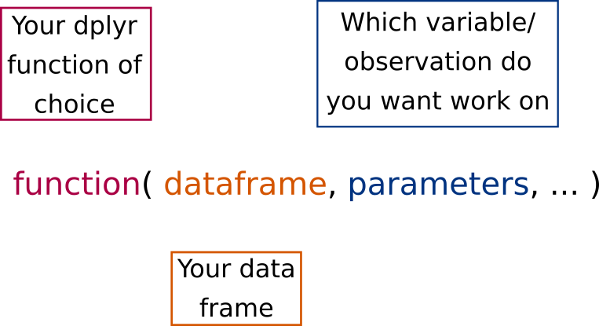

dplyr

## dplyr::select - (pt1)

```r
# Select one variable (common_name)
select(df1, common_name)
```

```
## # A tibble: 97 x 1
##    common_name
##    <chr>
##  1 Chinook salmon
##  2 Sockeye salmon
##  3 Sockeye salmon
##  4 Steelhead
##  5 Steelhead
##  6 Chinook salmon
##  7 Sockeye salmon
##  8 Steelhead
##  9 Steelhead
## 10 Steelhead
## # … with 87 more rows
```

## dplyr::select - (pt2)

**Select** allows you to make a dataframe from several variables

```r
# Select two variables (age_classbylength and common_name)
select(df1, age_classbylength, common_name)
```

```
## # A tibble: 97 x 2
##    age_classbylength  common_name
##    <chr>              <chr>
##  1 yearling           Chinook salmon
##  2 juvenile           Sockeye salmon
##  3 juvenile           Sockeye salmon
##  4 juvenile           Steelhead
##  5 juvenile           Steelhead
##  6 mixed age juvenile Chinook salmon
##  7 juvenile           Sockeye salmon
##  8 juvenile           Steelhead
##  9 juvenile           Steelhead
## 10 juvenile           Steelhead
## # … with 87 more rows
```

## dplyr::select - (pt3)

**Select** allows you to make a dataframe excluding a variable

```r
# Select all but one variable (length_mm)
select(df1,-length_mm)
```

```
## # A tibble: 97 x 4
##    salmon_id common_name    age_classbylength  IGF1_ng_ml
##        <dbl> <chr>          <chr>                   <dbl>
##  1     35032 Chinook salmon yearling                 41.3
##  2     35035 Sockeye salmon juvenile                 NA
##  3     35036 Sockeye salmon juvenile                 NA
##  4     35037 Steelhead      juvenile                 42.7
##  5     35038 Steelhead      juvenile                 NA
##  6     35033 Chinook salmon mixed age juvenile       62.1
##  7     35034 Sockeye salmon juvenile                 NA
##  8     35048 Steelhead      juvenile                 24.2
##  9     35049 Steelhead      juvenile                 NA
## 10     35050 Steelhead      juvenile                 63.5
## # … with 87 more rows
```

## dplyr::select - (pt4)

**Select** allows you to make a dataframe from a range of variables

```r
# Select all a range of contiguous varibles (common_name:length_mm)
select(df1, common_name:length_mm)
```

```
## # A tibble: 97 x 3
##    common_name    age_classbylength  length_mm
##    <chr>          <chr>                  <dbl>
##  1 Chinook salmon yearling                 147
##  2 Sockeye salmon juvenile                 121
##  3 Sockeye salmon juvenile                 112
##  4 Steelhead      juvenile                 220
##  5 Steelhead      juvenile                 152
##  6 Chinook salmon mixed age juvenile       444
##  7 Sockeye salmon juvenile                 139
##  8 Steelhead      juvenile                 288
##  9 Steelhead      juvenile                 190
## 10 Steelhead      juvenile                 283
## # … with 87 more rows
```

## dplyr::filter - (pt1)

**Filter** allows you to access observations based on a criteria

```r
# Filter all observation where the variable common_name is Sockeye salmon
filter(df1, common_name == 'Sockeye salmon')
```

```
## # A tibble: 11 x 5
##    salmon_id common_name    age_classbylength length_mm IGF1_ng_ml
##        <dbl> <chr>          <chr>                 <dbl>      <dbl>
##  1     35035 Sockeye salmon juvenile                121         NA
##  2     35036 Sockeye salmon juvenile                112         NA
##  3     35034 Sockeye salmon juvenile                139         NA
##  4     35144 Sockeye salmon juvenile                140         NA
##  5     35147 Sockeye salmon juvenile                115         NA
##  6     35096 Sockeye salmon juvenile                115         NA
##  7     35097 Sockeye salmon juvenile                110         NA
##  8     35098 Sockeye salmon juvenile                112         NA
##  9     35099 Sockeye salmon juvenile                111         NA
## 10     35100 Sockeye salmon juvenile                118         NA
## 11     35119 Sockeye salmon juvenile                122         NA
```

## dplyr::filter - (pt2)

**Filter** allows you to access observations based on several criteria

```r
# Filter all observations where the variable common_name is either Sockeye salmon or Chinook Salmon
filter(df1, common_name %in% c('Sockeye salmon', 'Chinook salmon'))
```

```
## # A tibble: 57 x 5
##    salmon_id common_name    age_classbylength  length_mm IGF1_ng_ml
##        <dbl> <chr>          <chr>                  <dbl>      <dbl>
##  1     35032 Chinook salmon yearling                 147       41.3
##  2     35035 Sockeye salmon juvenile                 121       NA
##  3     35036 Sockeye salmon juvenile                 112       NA
##  4     35033 Chinook salmon mixed age juvenile       444       62.1
##  5     35034 Sockeye salmon juvenile                 139       NA
##  6     35142 Chinook salmon yearling                 149       66.5
##  7     35143 Chinook salmon yearling                 204       80.9
##  8     35144 Sockeye salmon juvenile                 140       NA
##  9     35145 Chinook salmon yearling                 130       23.4
## 10     35146 Chinook salmon mixed age juvenile       422      101.
## # … with 47 more rows
```

## dplyr::filter - (pt3)

**Filter** allows you to access observations based on specific strings

```r
# Filter all observations where the variable common_name ends with 'salmon'. To do this we use stringr function str_ends recognise strings that end with 'salmon'.
filter(df1, str_ends(common_name, 'salmon'))
```

```
## # A tibble: 59 x 5
##    salmon_id common_name    age_classbylength  length_mm IGF1_ng_ml
##        <dbl> <chr>          <chr>                  <dbl>      <dbl>
##  1     35032 Chinook salmon yearling                 147       41.3
##  2     35035 Sockeye salmon juvenile                 121       NA
##  3     35036 Sockeye salmon juvenile                 112       NA
##  4     35033 Chinook salmon mixed age juvenile       444       62.1
##  5     35034 Sockeye salmon juvenile                 139       NA
##  6     35142 Chinook salmon yearling                 149       66.5
##  7     35143 Chinook salmon yearling                 204       80.9
##  8     35144 Sockeye salmon juvenile                 140       NA
##  9     35145 Chinook salmon yearling                 130       23.4
## 10     35146 Chinook salmon mixed age juvenile       422      101.
## # … with 49 more rows
```

## dplyr::filter - (pt4)

**Filter** allows you to access observations based on operators

```r
# Filter all observations where the variable length_mm is greater than 200 or less than 120
filter(df1, length_mm > 200 | length_mm < 120)
```

```
## # A tibble: 36 x 5
##    salmon_id common_name    age_classbylength  length_mm IGF1_ng_ml
##        <dbl> <chr>          <chr>                  <dbl>      <dbl>
##  1     35036 Sockeye salmon juvenile                 112       NA
##  2     35037 Steelhead      juvenile                 220       42.7
##  3     35033 Chinook salmon mixed age juvenile       444       62.1
##  4     35048 Steelhead      juvenile                 288       24.2
##  5     35050 Steelhead      juvenile                 283       63.5
##  6     35051 Steelhead      juvenile                 279       61.2
##  7     35052 Steelhead      juvenile                 235       30.6
##  8     35053 Steelhead      juvenile                 230       49.4
##  9     35056 Steelhead      juvenile                 208       57.4
## 10     35057 Steelhead      juvenile                 240       20.2
## # … with 26 more rows
```

## CHALLENGE: Time for an exercise!

Exercise on dplyr’s select and filter can be found [here](http://rockefelleruniversity.github.io/RU_tidyverse/tidyR/exercises/EX1_RU_tidyverse_dplyr_select_and_filter.html)

### Answers to exercise.

Answers can be found [here](http://rockefelleruniversity.github.io/RU_tidyverse/tidyR/answers/EX1_ANSWERS_RU_tidyverse_dplyr_select_and_filter.html)

R code for solutions can be found [here](http://rockefelleruniversity.github.io/RU_tidyverse/tidyR/answers/EX1_ANSWERS_RU_tidyverse_dplyr_select_and_filter.R)

## dplyr::arrange - (pt1)

*Arrange* sorts the dataframe based on a specific variable

```r
# Arrange the data based on the variable length_mm
arrange(df1, length_mm)
```

```
## # A tibble: 97 x 5
##    salmon_id common_name    age_classbylength length_mm IGF1_ng_ml
##        <dbl> <chr>          <chr>                 <dbl>      <dbl>
##  1     35095 Chinook salmon subyearling              90         NA
##  2     35097 Sockeye salmon juvenile                110         NA
##  3     35099 Sockeye salmon juvenile                111         NA
##  4     35036 Sockeye salmon juvenile                112         NA
##  5     35098 Sockeye salmon juvenile                112         NA
##  6     35147 Sockeye salmon juvenile                115         NA
##  7     35096 Sockeye salmon juvenile                115         NA
##  8     35100 Sockeye salmon juvenile                118         NA
##  9     35035 Sockeye salmon juvenile                121         NA
## 10     35119 Sockeye salmon juvenile                122         NA
## # … with 87 more rows
```

## dplyr::arrange - (pt2)

*Arrange* sorts the dataframe based on specific variables

```r
# Arrange the data first based on the variable common_name,
# then secondly based on length_mm in a descending order.
arrange(df1, common_name, desc(length_mm))
```

```
## # A tibble: 97 x 5
##    salmon_id common_name    age_classbylength  length_mm IGF1_ng_ml
##        <dbl> <chr>          <chr>                  <dbl>      <dbl>
##  1     35033 Chinook salmon mixed age juvenile       444      62.1
##  2     35146 Chinook salmon mixed age juvenile       422     101.
##  3     35110 Chinook salmon mixed age juvenile       275      81.5
##  4     35129 Chinook salmon yearling                 225      72.7
##  5     35103 Chinook salmon yearling                 216      81.2
##  6     35115 Chinook salmon yearling                 215      53.5
##  7     35112 Chinook salmon yearling                 205      90.5
##  8     35143 Chinook salmon yearling                 204      80.9
##  9     35079 Chinook salmon yearling                 199      53.2
## 10     35081 Chinook salmon yearling                 196       5.56
## # … with 87 more rows
```

## dplyr::mutate - (pt1)

*Mutate* creates a new variable based on some form of computation

```r
# A new variable is created based on the calculation of the
# z-score of the variable IGF1_ng_ml using scale()
mutate(df1, scale(IGF1_ng_ml))
```

```
## # A tibble: 97 x 6
##    salmon_id common_name    age_classbylength  length_mm IGF1_ng_ml `scale(IGF1_ng_ml)`[,1]
##        <dbl> <chr>          <chr>                  <dbl>      <dbl>                   <dbl>
##  1     35032 Chinook salmon yearling                 147       41.3                  -0.258
##  2     35035 Sockeye salmon juvenile                 121       NA                    NA
##  3     35036 Sockeye salmon juvenile                 112       NA                    NA
##  4     35037 Steelhead      juvenile                 220       42.7                  -0.191
##  5     35038 Steelhead      juvenile                 152       NA                    NA
##  6     35033 Chinook salmon mixed age juvenile       444       62.1                   0.704
##  7     35034 Sockeye salmon juvenile                 139       NA                    NA
##  8     35048 Steelhead      juvenile                 288       24.2                  -1.04
##  9     35049 Steelhead      juvenile                 190       NA                    NA
## 10     35050 Steelhead      juvenile                 283       63.5                   0.766
## # … with 87 more rows
```

## dplyr::mutate - (pt2)

*Mutate* creates a named variable based on some form of computation

```r
# A new variable is created called IGFngml_zscore, based on the
# calculation of the z-score of the variable IGF1_ng_ml using scale()
mutate(df1, IGFngml_zscore = scale(IGF1_ng_ml))
```

```
## # A tibble: 97 x 6
##    salmon_id common_name    age_classbylength  length_mm IGF1_ng_ml IGFngml_zscore[,1]
##        <dbl> <chr>          <chr>                  <dbl>      <dbl>              <dbl>
##  1     35032 Chinook salmon yearling                 147       41.3             -0.258
##  2     35035 Sockeye salmon juvenile                 121       NA               NA
##  3     35036 Sockeye salmon juvenile                 112       NA               NA
##  4     35037 Steelhead      juvenile                 220       42.7             -0.191
##  5     35038 Steelhead      juvenile                 152       NA               NA
##  6     35033 Chinook salmon mixed age juvenile       444       62.1              0.704
##  7     35034 Sockeye salmon juvenile                 139       NA               NA
##  8     35048 Steelhead      juvenile                 288       24.2             -1.04
##  9     35049 Steelhead      juvenile                 190       NA               NA
## 10     35050 Steelhead      juvenile                 283       63.5              0.766
## # … with 87 more rows
```

## CHALLENGE: Time for an exercise!

Exercise on dplyr’s arrange and mutate can be found [here](http://rockefelleruniversity.github.io/RU_tidyverse/tidyR/exercises/EX2_RU_tidyverse_dplyr_arrange_and_mutate.html)

### Answers to exercise.

Answers can be found [here](http://rockefelleruniversity.github.io/RU_tidyverse/tidyR/answers/EX2_ANSWERS_RU_tidyverse_dplyr_arrange_and_mutate.html)

R code for solutions can be found [here](http://rockefelleruniversity.github.io/RU_tidyverse/tidyR/answers/EX2_ANSWERS_RU_tidyverse_dplyr_arrange_and_mutate.R)

## dplyr::summarize - (pt1)

*Summarize* applies aggregating or summary function to a group i.e. counting

```r
# First we define the common_name as a group.
df1_byname <- group_by(df1, common_name)

# Summarise is used to count over the grouped common_names
summarise(df1_byname, count = n())
```

```
## # A tibble: 4 x 2
##   common_name    count
##   <chr>          <int>
## 1 Chinook salmon    46
## 2 Coho salmon        2
## 3 Sockeye salmon    11
## 4 Steelhead         38
```

## dplyr::summarize - (pt2)

*Summarize* applies aggregating or summary function to a group i.e. means

```r
# Summarise is used to calculate mean IGF1_ng_ml over the
# grouped common_names
summarise(df1_byname, IGF1_ng_ml_ave = mean(IGF1_ng_ml, na.rm = T))
```

```
## # A tibble: 4 x 2
##   common_name    IGF1_ng_ml_ave
##   <chr>                   <dbl>
## 1 Chinook salmon           46.8
## 2 Coho salmon              73.6
## 3 Sockeye salmon          NaN
## 4 Steelhead                46.1
```

## dplyr::group_by - (pt1)

*Grouping* can also help filter within groups

```r
# Filter observations with the 2 smallest length_mm for each grouped common_names
filter(df1_byname, rank(length_mm) <= 2)
```

```
## # A tibble: 8 x 5
## # Groups:   common_name [4]
##   salmon_id common_name    age_classbylength length_mm IGF1_ng_ml
##       <dbl> <chr>          <chr>                 <dbl>      <dbl>
## 1     35038 Steelhead      juvenile                152       NA
## 2     35055 Steelhead      juvenile                123       55.7
## 3     35145 Chinook salmon yearling                130       23.4
## 4     35085 Coho salmon    yearling                140       NA
## 5     35087 Coho salmon    yearling                164       73.6
## 6     35095 Chinook salmon subyearling              90       NA
## 7     35097 Sockeye salmon juvenile                110       NA
## 8     35099 Sockeye salmon juvenile                111       NA
```

## dplyr::group_by - (pt2)

*Grouping* can also help filter within groups

```r
# Filter observations with at least 5 for each grouped common_names
filter(df1_byname, n() > 5)
```

```
## # A tibble: 95 x 5
## # Groups:   common_name [3]
##    salmon_id common_name    age_classbylength  length_mm IGF1_ng_ml
##        <dbl> <chr>          <chr>                  <dbl>      <dbl>
##  1     35032 Chinook salmon yearling                 147       41.3
##  2     35035 Sockeye salmon juvenile                 121       NA
##  3     35036 Sockeye salmon juvenile                 112       NA
##  4     35037 Steelhead      juvenile                 220       42.7
##  5     35038 Steelhead      juvenile                 152       NA
##  6     35033 Chinook salmon mixed age juvenile       444       62.1
##  7     35034 Sockeye salmon juvenile                 139       NA
##  8     35048 Steelhead      juvenile                 288       24.2
##  9     35049 Steelhead      juvenile                 190       NA
## 10     35050 Steelhead      juvenile                 283       63.5
## # … with 85 more rows
```

## dplyr::group_by - (pt3)

*Grouping* creates a new variable based on some form of computation within the group

```r
# A new variable is created using z-score within the grouped common_names
mutate(df1_byname, IGFngml_zscore = scale(IGF1_ng_ml))
```

```
## # A tibble: 97 x 6
## # Groups:   common_name [4]
##    salmon_id common_name    age_classbylength  length_mm IGF1_ng_ml IGFngml_zscore
##        <dbl> <chr>          <chr>                  <dbl>      <dbl>          <dbl>
##  1     35032 Chinook salmon yearling                 147       41.3         -0.236
##  2     35035 Sockeye salmon juvenile                 121       NA           NA
##  3     35036 Sockeye salmon juvenile                 112       NA           NA
##  4     35037 Steelhead      juvenile                 220       42.7         -0.176
##  5     35038 Steelhead      juvenile                 152       NA           NA
##  6     35033 Chinook salmon mixed age juvenile       444       62.1          0.652
##  7     35034 Sockeye salmon juvenile                 139       NA           NA
##  8     35048 Steelhead      juvenile                 288       24.2         -1.12
##  9     35049 Steelhead      juvenile                 190       NA           NA
## 10     35050 Steelhead      juvenile                 283       63.5          0.890
## # … with 87 more rows
```

## CHALLENGE: Time for an exercise!

Exercise on dplyr’s grouping and summarize can be found [here](http://rockefelleruniversity.github.io/RU_tidyverse/tidyR/exercises/EX3_RU_tidyverse_dplyr_group_and_summarize.html)

### Answers to exercise.

Answers can be found [here](http://rockefelleruniversity.github.io/RU_tidyverse/tidyR/answers/EX3_ANSWERS_RU_tidyverse_dplyr_group_and_summarize.html)

R code for solutions can be found [here](http://rockefelleruniversity.github.io/RU_tidyverse/tidyR/answers/EX3_ANSWERS_RU_tidyverse_dplyr_group_and_summarize.R)

# Piping to string functions together

Piping was allows you to pass the result from one expression directly into another.  
magrittR package developed the %>% pipe which is integral to the tidy way of formatting code

The pattern is similar but now follows a specific logical flow:

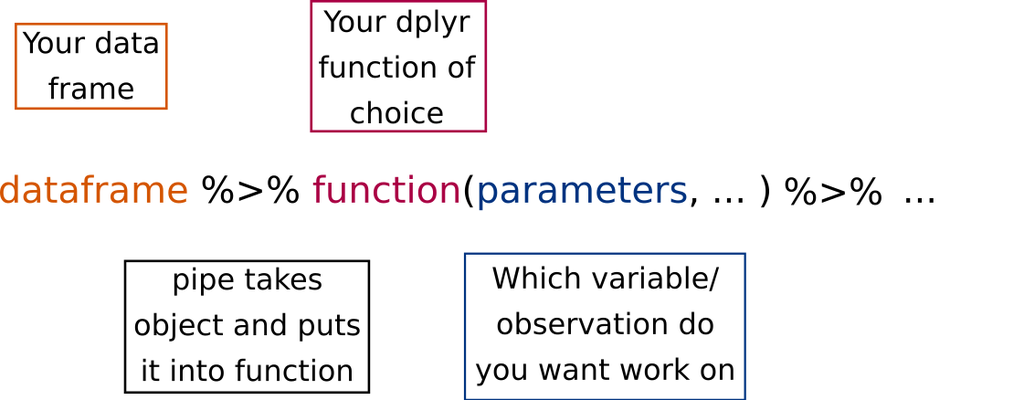

dplyr

## Piping vs. not piping

```r
# Without pipe
df1_byname <- group_by(df1, common_name)
summarise(df1_byname, IGF1_ng_ml_ave = mean(IGF1_ng_ml, na.rm=T))
```

```
## # A tibble: 4 x 2
##   common_name    IGF1_ng_ml_ave
##   <chr>                   <dbl>
## 1 Chinook salmon           46.8
## 2 Coho salmon              73.6
## 3 Sockeye salmon          NaN
## 4 Steelhead                46.1
```

```r
# With pipe
df1 %>%
  group_by(common_name) %>%
  summarise(IGF1_ng_ml_ave = mean(IGF1_ng_ml, na.rm=T))
```

```
## # A tibble: 4 x 2
##   common_name    IGF1_ng_ml_ave
##   <chr>                   <dbl>
## 1 Chinook salmon           46.8
## 2 Coho salmon              73.6
## 3 Sockeye salmon          NaN
## 4 Steelhead                46.1
```

## Linking functions with pipes - (pt1)

```r
# (1) Group by common_name
# (2) Filter to all those that have length bigger then 200
# (3) Summarise is used to calculate mean IGF1_ng_ml over the grouped
# common_names for these larger fish

df1 %>%
  group_by(common_name) %>%
  filter(length_mm > 200) %>%
  summarise(IGF1_ng_ml_ave = mean(IGF1_ng_ml, na.rm = T))
```

```
## # A tibble: 2 x 2
##   common_name    IGF1_ng_ml_ave
##   <chr>                   <dbl>
## 1 Chinook salmon           77.9
## 2 Steelhead                45.3
```

## Linking functions with pipes - (pt2)

```r
# (1) Create new variable that is discrete label depending on size of the fish
# (2) Group by common_name and size
# (3) Summarise is used to calculate mean IGF1_ng_ml over the grouped
# common_names and sizes

df1 %>%
  mutate(size = if_else(length_mm > 200, 'big_fish', 'small_fish')) %>%
  group_by(common_name, size) %>%
  summarise(IGF1_ng_ml_ave = mean(IGF1_ng_ml, na.rm = T))
```

```
## # A tibble: 6 x 3
## # Groups:   common_name [4]
##   common_name    size       IGF1_ng_ml_ave
##   <chr>          <chr>               <dbl>
## 1 Chinook salmon big_fish             77.9
## 2 Chinook salmon small_fish           39.5
## 3 Coho salmon    small_fish           73.6
## 4 Sockeye salmon small_fish          NaN
## 5 Steelhead      big_fish             45.3
## 6 Steelhead      small_fish           47.3
```

## Linking functions with pipes - (pt3)

```r
# (1) Create new variable that is discrete label depending on size of the fish
# (2) Group by common_name and size
# (3) Summarise is used to calculate mean IGF1_ng_ml over the grouped
# common_names and sizes
# (4) Filter out Coho and Sockeye salmon

df1 %>%
  mutate(size = if_else(length_mm > 200, 'big_fish', 'small_fish')) %>%
  group_by(common_name, size) %>%
  summarise(IGF1_ng_ml_ave = mean(IGF1_ng_ml, na.rm = T)) %>%
  filter(common_name != 'Coho salmon')  %>%
  filter(common_name !='Sockeye salmon')
```

```
## # A tibble: 4 x 3
## # Groups:   common_name [2]
##   common_name    size       IGF1_ng_ml_ave
##   <chr>          <chr>               <dbl>
## 1 Chinook salmon big_fish             77.9
## 2 Chinook salmon small_fish           39.5
## 3 Steelhead      big_fish             45.3
## 4 Steelhead      small_fish           47.3
```

## You can pipe straight to plots - (pt1)

```r
p <- df1 %>% mutate(size=if_else(length_mm>200, 'big_fish', 'small_fish')) %>%
  group_by(common_name, size) %>%
  summarize(IGF1_ng_ml_ave=mean(IGF1_ng_ml, na.rm=T)) %>%
  filter(common_name != 'Coho salmon')  %>%
  filter(common_name != 'Sockeye salmon') %>%
  ggplot(aes(x = common_name, y = IGF1_ng_ml_ave, group = size, fill = size)) +
  geom_bar(stat = "identity", position = "dodge") +
  theme(axis.text.x = element_text(angle = 90)) +
  scale_fill_brewer(palette = "Paired")
```

## You can pipe straight to plots - (pt2)

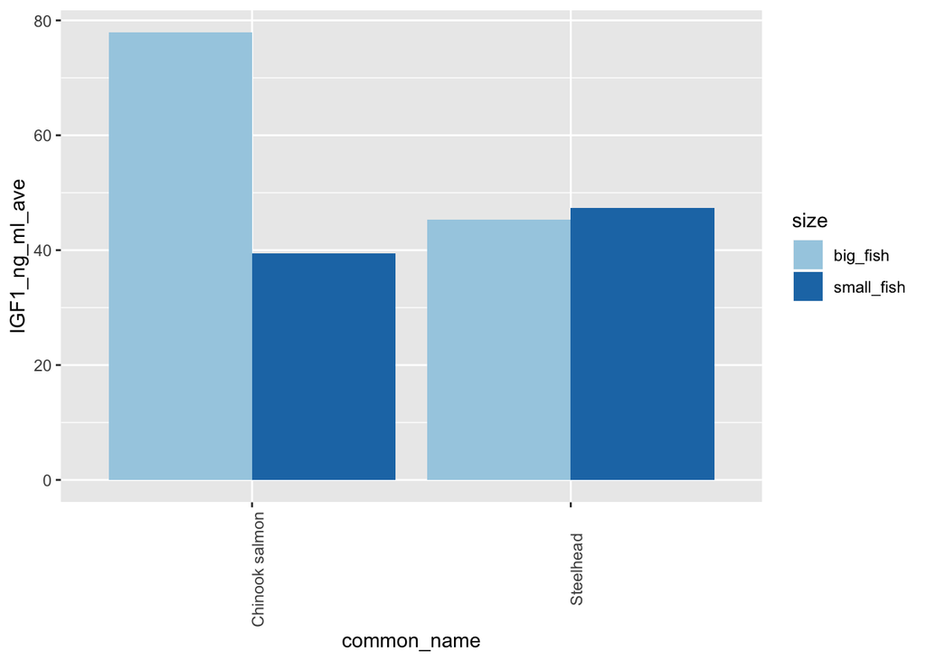

```r
p
```

## CHALLENGE: Time for an exercise!

Exercise on piping can be found [here](http://rockefelleruniversity.github.io/RU_tidyverse/tidyR/exercises/EX4_RU_tidyverse_pipes.html)

### Answers to exercise.

Answers can be found [here](http://rockefelleruniversity.github.io/RU_tidyverse/tidyR/answers/EX4_ANSWERS_RU_tidyverse_pipes.html)

R code for solutions can be found [here](http://rockefelleruniversity.github.io/RU_tidyverse/tidyR/answers/EX4_ANSWERS_RU_tidyverse_pipes.R)

# readr: Reading data into R

So we blasted through what being tidy can give you. Now lets start from the beginning and tidy some data. First step is to read in data.

readr:

- read_csv(): comma separated (CSV) files
- read_tsv(): tab separated files
- read_delim(): general delimited files
- read_fwf(): fixed width files
- read_table(): tabular files where columns are separated by white-space
- read_log(): web log files

## Reading in with base

```r
untidy_counts_base <- read.csv("dataset/hemato_rnaseq_counts.csv")
# Base will print out everything
untidy_counts_base
```

```
##     ENTREZ CD34_1 ORTHO_1 CD34_2 ORTHO_2
## 1      350    204       0    103       0
## 2      351  15586     479  10476      39
## 3      353    842     355   1188      86
## 4      354      0       0      0       0
## 5      355    123     291    139      16
## 6      356      1       1      0       0
## 7      357    380       3    177       0
## 8      358    572    2225    597    4051
## 9      359      0      12      1       0
## 10     360    320     502     46    1114
## 11     361      0       1      0       0
## 12     362      3       1     15       0
## 13     363     14       6      4       1
## 14     364      7       0      1       0
```

[output cut: 86 more lines]

## Reading in with readr - (pt1)

```r
# readr gives you a tibble.
read_csv("dataset/hemato_rnaseq_counts.csv")
```

```
## # A tibble: 100 x 5
##    ENTREZ CD34_1 ORTHO_1 CD34_2 ORTHO_2
##     <dbl>  <dbl>   <dbl>  <dbl>   <dbl>
##  1    350    204       0    103       0
##  2    351  15586     479  10476      39
##  3    353    842     355   1188      86
##  4    354      0       0      0       0
##  5    355    123     291    139      16
##  6    356      1       1      0       0
##  7    357    380       3    177       0
##  8    358    572    2225    597    4051
##  9    359      0      12      1       0
## 10    360    320     502     46    1114
## # … with 90 more rows
```

## Reading in with readr - (pt2)

```r
# Tibbles carry and display extra information.
# While reading in it is easy to specify data type.
untidy_counts <- read_csv("dataset/hemato_rnaseq_counts.csv", col_types = cols(
    ENTREZ = col_character(),
    CD34_1 = col_integer(),
    ORTHO_1 = col_integer(),
    CD34_2 = col_integer(),
    ORTHO_2 = col_integer()
  ))
untidy_counts
```

```
## # A tibble: 100 x 5
##    ENTREZ CD34_1 ORTHO_1 CD34_2 ORTHO_2
##    <chr>   <int>   <int>  <int>   <int>
##  1 350       204       0    103       0
##  2 351     15586     479  10476      39
##  3 353       842     355   1188      86
##  4 354         0       0      0       0
##  5 355       123     291    139      16
##  6 356         1       1      0       0
##  7 357       380       3    177       0
##  8 358       572    2225    597    4051
##  9 359         0      12      1       0
## 10 360       320     502     46    1114
## # … with 90 more rows
```

## Subsetting to make tibbles - (pt1)

```r
# Can use the same way as base to interact with the
# tibble dataframe - columns
untidy_counts[,1]
```

```
## # A tibble: 100 x 1
##    ENTREZ
##    <chr>
##  1 350
##  2 351
##  3 353
##  4 354
##  5 355
##  6 356
##  7 357
##  8 358
##  9 359
## 10 360
## # … with 90 more rows
```

## Subsetting to make tibbles - (pt2)

```r
# Can use the same way as base to interact with the
# tibble dataframe - rows
untidy_counts[1,]
```

```
## # A tibble: 1 x 5
##   ENTREZ CD34_1 ORTHO_1 CD34_2 ORTHO_2
##   <chr>   <int>   <int>  <int>   <int>
## 1 350       204       0    103       0
```

## Subsetting to make tibbles - (pt3)

```r
# Can also not specify which dimension you pull from.
# This will default to grabbing the column
untidy_counts[1]
```

```
## # A tibble: 100 x 1
##    ENTREZ
##    <chr>
##  1 350
##  2 351
##  3 353
##  4 354
##  5 355
##  6 356
##  7 357
##  8 358
##  9 359
## 10 360
## # … with 90 more rows
```

## Subsetting to make vectors - (pt1)

```r
# All the prior outputs have been outputting another tibble.
# If double brackets are used a vector is returned
untidy_counts[[1]]
```

```
##   [1] "350" "351" "353" "354" "355" "356" "357" "358" "359" "360" "361" "362" "363" "364" "366"
##  [16] "367" "368" "369" "372" "373" "374" "375" "377" "378" "379" "381" "382" "383" "384" "387"
##  [31] "388" "389" "390" "391" "392" "393" "394" "395" "396" "397" "398" "399" "400" "401" "402"
##  [46] "403" "405" "406" "407" "408" "409" "410" "411" "412" "414" "415" "416" "417" "419" "420"
##  [61] "421" "427" "429" "430" "432" "433" "434" "435" "440" "443" "444" "445" "460" "462" "463"
##  [76] "466" "467" "468" "471" "472" "473" "474" "475" "476" "477" "478" "479" "480" "481" "482"
##  [91] "483" "486" "487" "488" "489" "490" "491" "492" "493" "495"
```

## Subsetting to make vectors - (pt2)

```r
# This is also the case if you use the dollar and colname
# to access a column
untidy_counts$ENTREZ
```

```
##   [1] "350" "351" "353" "354" "355" "356" "357" "358" "359" "360" "361" "362" "363" "364" "366"
##  [16] "367" "368" "369" "372" "373" "374" "375" "377" "378" "379" "381" "382" "383" "384" "387"
##  [31] "388" "389" "390" "391" "392" "393" "394" "395" "396" "397" "398" "399" "400" "401" "402"
##  [46] "403" "405" "406" "407" "408" "409" "410" "411" "412" "414" "415" "416" "417" "419" "420"
##  [61] "421" "427" "429" "430" "432" "433" "434" "435" "440" "443" "444" "445" "460" "462" "463"
##  [76] "466" "467" "468" "471" "472" "473" "474" "475" "476" "477" "478" "479" "480" "481" "482"
##  [91] "483" "486" "487" "488" "489" "490" "491" "492" "493" "495"
```

## CHALLENGE: Time for an exercise!

Exercise on readr can be found [here](http://rockefelleruniversity.github.io/RU_tidyverse/tidyR/exercises/EX5_RU_tidyverse_readr.html)

### Answers to exercise.

Answers can be found [here](http://rockefelleruniversity.github.io/RU_tidyverse/tidyR/answers/EX5_ANSWERS_RU_tidyverse_readr.html)

R code for solutions can be found [here](http://rockefelleruniversity.github.io/RU_tidyverse/tidyR/answers/EX5_ANSWERS_RU_tidyverse_readr.R)

## Tibbles: Converting to tibble - (pt1)

```r
# Can convert base dataframes into tibbles
as_tibble(untidy_counts_base)
```

```
## # A tibble: 100 x 5
##    ENTREZ CD34_1 ORTHO_1 CD34_2 ORTHO_2
##     <int>  <int>   <int>  <int>   <int>
##  1    350    204       0    103       0
##  2    351  15586     479  10476      39
##  3    353    842     355   1188      86
##  4    354      0       0      0       0
##  5    355    123     291    139      16
##  6    356      1       1      0       0
##  7    357    380       3    177       0
##  8    358    572    2225    597    4051
##  9    359      0      12      1       0
## 10    360    320     502     46    1114
## # … with 90 more rows
```

## Tibbles: Converting to tibble - (pt2)

```r
# Once it is a tibble it is straight forward to modify the datatype
untidy_counts_base <- as_tibble(untidy_counts_base) %>%
  mutate_at(vars(ENTREZ), as.character)
untidy_counts_base
```

```
## # A tibble: 100 x 5
##    ENTREZ CD34_1 ORTHO_1 CD34_2 ORTHO_2
##    <chr>   <int>   <int>  <int>   <int>
##  1 350       204       0    103       0
##  2 351     15586     479  10476      39
##  3 353       842     355   1188      86
##  4 354         0       0      0       0
##  5 355       123     291    139      16
##  6 356         1       1      0       0
##  7 357       380       3    177       0
##  8 358       572    2225    597    4051
##  9 359         0      12      1       0
## 10 360       320     502     46    1114
## # … with 90 more rows
```

## Tibbles: Converting from tibble

```r
# Some tools are not tibble friendly. Calling as.data.frame is
# sufficient to convert it back to a base data frame
as.data.frame(untidy_counts_base) %>% head(n=12)
```

```
##    ENTREZ CD34_1 ORTHO_1 CD34_2 ORTHO_2
## 1     350    204       0    103       0
## 2     351  15586     479  10476      39
## 3     353    842     355   1188      86
## 4     354      0       0      0       0
## 5     355    123     291    139      16
## 6     356      1       1      0       0
## 7     357    380       3    177       0
## 8     358    572    2225    597    4051
## 9     359      0      12      1       0
## 10    360    320     502     46    1114
## 11    361      0       1      0       0
## 12    362      3       1     15       0
```

## Tibbles: Make your own - (pt1)

**We will make our own tibble now from scratch, using some metadata that will be useful later**

```r
# Lets load in some packages
library(org.Hs.eg.db)
library(TxDb.Hsapiens.UCSC.hg19.knownGene)

# Lets use the ENTREZ ID as a key
keys <- untidy_counts$ENTREZ

# We can use the ENTREZ ID to look up Gene Symbol
symbols <- select(org.Hs.eg.db, keys = keys,columns = "SYMBOL", keytype = "ENTREZID")

# We can use the ENTREZ ID to look up the chormosome the gene resides on
chrs <- select(TxDb.Hsapiens.UCSC.hg19.knownGene, keys = keys, columns = "TXCHROM", keytype = "GENEID")

# We can use the ENTREZ ID to get a list of genes with grange of their exons
geneExons <- exonsBy(TxDb.Hsapiens.UCSC.hg19.knownGene,by = "gene")[keys]
```

## Tibbles: Make your own - (pt2)

```r
# We will then use an apply to get the transcript length from each gene in the
# list. The transcript length is calculated by first flattening overlapping
# exons with reduce(), then calculating the length of each exon with width(),
# then summing upthe total exon length to get our transcript length.
txsLength <- sapply(geneExons, function(x){ x %>%
    GenomicRanges::reduce() %>%
    width() %>%
    sum() })

# Finally we have all this metadata. Lets put it together into a tibble.
counts_metadata <- tibble(ID = symbols$ENTREZID, SYMBOL = symbols$SYMBOL, CHR = chrs$TXCHROM, LENGTH = txsLength)
```

## Tibbles: Make your own - (pt3)

```r
counts_metadata
```

```
## # A tibble: 100 x 4
##    ID    SYMBOL  CHR   LENGTH
##    <chr> <chr>   <chr>  <int>
##  1 350   APOH    chr17   1201
##  2 351   APP     chr21   4480
##  3 353   APRT    chr16    807
##  4 354   KLK3    chr19   1906
##  5 355   FAS     chr10   6691
##  6 356   FASLG   chr1    1859
##  7 357   SHROOM2 chrX    8206
##  8 358   AQP1    chr7    3786
##  9 359   AQP2    chr12   4179
## 10 360   AQP3    chr9    2950
## # … with 90 more rows
```

# Tidying data up

What is wrong with the count dataframe from a tidy viewpoint?

*Remember*. These are the rules:

- Each variable has its own column
- Each observation has its own row
- Each value has its own cell

```r
untidy_counts
```

```
## # A tibble: 100 x 5
##    ENTREZ CD34_1 ORTHO_1 CD34_2 ORTHO_2
##    <chr>   <int>   <int>  <int>   <int>
##  1 350       204       0    103       0
##  2 351     15586     479  10476      39
##  3 353       842     355   1188      86
##  4 354         0       0      0       0
##  5 355       123     291    139      16
##  6 356         1       1      0       0
##  7 357       380       3    177       0
##  8 358       572    2225    597    4051
##  9 359         0      12      1       0
## 10 360       320     502     46    1114
## # … with 90 more rows
```

## Tidying data up

What is wrong with the count dataframe from a tidy viewpoint?

*Remember*, these are the rules:

- Each variable has its own column
- Each observation has its own row
- Each value has its own cell

**A single variable with multiple columns**

```r
untidy_counts
```

```
## # A tibble: 100 x 5
##    ENTREZ CD34_1 ORTHO_1 CD34_2 ORTHO_2
##    <chr>   <int>   <int>  <int>   <int>
##  1 350       204       0    103       0
##  2 351     15586     479  10476      39
##  3 353       842     355   1188      86
##  4 354         0       0      0       0
##  5 355       123     291    139      16
##  6 356         1       1      0       0
##  7 357       380       3    177       0
##  8 358       572    2225    597    4051
##  9 359         0      12      1       0
## 10 360       320     502     46    1114
## # … with 90 more rows
```

## Reshape data with gather and spread

When all the content is in the data frame, but it is in the wrong orientation, tidyr has some tools to move the data around quickly and easily:

**gather and spread**

## tidyr::gather

Gather allows you to collapse single varibles that are spread over multiple columns

```r
# New columns Sample and Counts are created from whole dataframe
tidier_counts <- gather(untidy_counts, key="Sample", value="counts", -ENTREZ)
tidier_counts
```

```
## # A tibble: 400 x 3
##    ENTREZ Sample counts
##    <chr>  <chr>   <int>
##  1 350    CD34_1    204
##  2 351    CD34_1  15586
##  3 353    CD34_1    842
##  4 354    CD34_1      0
##  5 355    CD34_1    123
##  6 356    CD34_1      1
##  7 357    CD34_1    380
##  8 358    CD34_1    572
##  9 359    CD34_1      0
## 10 360    CD34_1    320
## # … with 390 more rows
```

## tidyr::spread

Spread allows you to spread single variables over multiple columns

```r
spread(tidier_counts, key="Sample", value="counts")
```

```
## # A tibble: 100 x 5
##    ENTREZ CD34_1 CD34_2 ORTHO_1 ORTHO_2
##    <chr>   <int>  <int>   <int>   <int>
##  1 350       204    103       0       0
##  2 351     15586  10476     479      39
##  3 353       842   1188     355      86
##  4 354         0      0       0       0
##  5 355       123    139     291      16
##  6 356         1      0       1       0
##  7 357       380    177       3       0
##  8 358       572    597    2225    4051
##  9 359         0      1      12       0
## 10 360       320     46     502    1114
## # … with 90 more rows
```

## tidyr::pivot_longer/pivot_wider

Gather and spread are being retired. They are being replaced with pivot_tools.  
There is slightly different nomencalture, but they pretty much do the same thing.

```r
#
pivot_longer(untidy_counts,names_to = "Sample", values_to = "counts", cols = c(-ENTREZ))
gather(untidy_counts, key=Sample, value=counts, -ENTREZ)
#
pivot_wider(tidier_counts, names_from = c(Sample), values_from = counts)
spread(tidier_counts, key=Sample, value=counts)
```

## CHALLENGE: Time for an exercise!

Exercise on tidying can be found [here](http://rockefelleruniversity.github.io/RU_tidyverse/tidyR/exercises/EX6_RU_tidyverse_tidying.html)

### Answers to exercise.

Answers can be found [here](http://rockefelleruniversity.github.io/RU_tidyverse/tidyR/answers/EX6_ANSWERS_RU_tidyverse_tidying.html)

R code for solutions can be found [here](http://rockefelleruniversity.github.io/RU_tidyverse/tidyR/answers/EX6_ANSWERS_RU_tidyverse_tidying.R)

## What is next to tidy?

*Remember*, these are the rules:

- Each variable has its own column
- Each observation has its own row
- Each value has its own cell

```r
tidier_counts
```

```
## # A tibble: 400 x 3
##    ENTREZ Sample counts
##    <chr>  <chr>   <int>
##  1 350    CD34_1    204
##  2 351    CD34_1  15586
##  3 353    CD34_1    842
##  4 354    CD34_1      0
##  5 355    CD34_1    123
##  6 356    CD34_1      1
##  7 357    CD34_1    380
##  8 358    CD34_1    572
##  9 359    CD34_1      0
## 10 360    CD34_1    320
## # … with 390 more rows
```

## What is next to tidy?

*Remember*, these are the rules:

- Each variable has its own column
- Each observation has its own row
- Each value has its own cell

**Multiple variables in a single column**

```r
tidier_counts
```

```
## # A tibble: 400 x 3
##    ENTREZ Sample counts
##    <chr>  <chr>   <int>
##  1 350    CD34_1    204
##  2 351    CD34_1  15586
##  3 353    CD34_1    842
##  4 354    CD34_1      0
##  5 355    CD34_1    123
##  6 356    CD34_1      1
##  7 357    CD34_1    380
##  8 358    CD34_1    572
##  9 359    CD34_1      0
## 10 360    CD34_1    320
## # … with 390 more rows
```

## Splitting and combining varaibles

When there are several variables crammed into a single column, tidyr can be used to split single values into several:

**separate**

## tidyr::separate - (pt1)

```r
# Separate allows you to break a strings in a variable by a separator.
# In this case the cell type and replicate number are broken by underscore
tidier_counts <- separate(tidier_counts, Sample, sep = "_", into=c("CellType","Rep"), remove=TRUE)
tidier_counts
```

```
## # A tibble: 400 x 4
##    ENTREZ CellType Rep   counts
##    <chr>  <chr>    <chr>  <int>
##  1 350    CD34     1        204
##  2 351    CD34     1      15586
##  3 353    CD34     1        842
##  4 354    CD34     1          0
##  5 355    CD34     1        123
##  6 356    CD34     1          1
##  7 357    CD34     1        380
##  8 358    CD34     1        572
##  9 359    CD34     1          0
## 10 360    CD34     1        320
## # … with 390 more rows
```

## tidyr::unite

```r
# Unite can go the other way. This can sometime be useful i.e. if you want a specific sample ID
unite(tidier_counts, Sample, CellType, Rep, remove=FALSE)
```

```
## # A tibble: 400 x 5
##    ENTREZ Sample CellType Rep   counts
##    <chr>  <chr>  <chr>    <chr>  <int>
##  1 350    CD34_1 CD34     1        204
##  2 351    CD34_1 CD34     1      15586
##  3 353    CD34_1 CD34     1        842
##  4 354    CD34_1 CD34     1          0
##  5 355    CD34_1 CD34     1        123
##  6 356    CD34_1 CD34     1          1
##  7 357    CD34_1 CD34     1        380
##  8 358    CD34_1 CD34     1        572
##  9 359    CD34_1 CD34     1          0
## 10 360    CD34_1 CD34     1        320
## # … with 390 more rows
```

## tidyr::separate - (pt2)

```r
# Remember you can always pipe everything together into a single expression
tidy_counts <- untidy_counts %>%
  gather(key=Sample, value=counts, -ENTREZ) %>%
  separate(Sample, sep = "_", into = c("CellType","Rep"), remove=FALSE)
tidy_counts
```

```
## # A tibble: 400 x 5
##    ENTREZ Sample CellType Rep   counts
##    <chr>  <chr>  <chr>    <chr>  <int>
##  1 350    CD34_1 CD34     1        204
##  2 351    CD34_1 CD34     1      15586
##  3 353    CD34_1 CD34     1        842
##  4 354    CD34_1 CD34     1          0
##  5 355    CD34_1 CD34     1        123
##  6 356    CD34_1 CD34     1          1
##  7 357    CD34_1 CD34     1        380
##  8 358    CD34_1 CD34     1        572
##  9 359    CD34_1 CD34     1          0
## 10 360    CD34_1 CD34     1        320
## # … with 390 more rows
```

# Joining

Data frames can be joined on a shared variable *a.k.a.* a key. We want this key to be unique i.e. ENTREZ ID.

## dplyr::inner_join - Merging dataframes

```r
tidy_counts
```

```
## # A tibble: 400 x 5
##    ENTREZ Sample CellType Rep   counts
##    <chr>  <chr>  <chr>    <chr>  <int>
##  1 350    CD34_1 CD34     1        204
##  2 351    CD34_1 CD34     1      15586
##  3 353    CD34_1 CD34     1        842
##  4 354    CD34_1 CD34     1          0
##  5 355    CD34_1 CD34     1        123
##  6 356    CD34_1 CD34     1          1
##  7 357    CD34_1 CD34     1        380
##  8 358    CD34_1 CD34     1        572
##  9 359    CD34_1 CD34     1          0
## 10 360    CD34_1 CD34     1        320
## # … with 390 more rows
```

## dplyr::inner_join - Merging dataframes

```r
counts_metadata
```

```
## # A tibble: 100 x 4
##    ID    SYMBOL  CHR   LENGTH
##    <chr> <chr>   <chr>  <int>
##  1 350   APOH    chr17   1201
##  2 351   APP     chr21   4480
##  3 353   APRT    chr16    807
##  4 354   KLK3    chr19   1906
##  5 355   FAS     chr10   6691
##  6 356   FASLG   chr1    1859
##  7 357   SHROOM2 chrX    8206
##  8 358   AQP1    chr7    3786
##  9 359   AQP2    chr12   4179
## 10 360   AQP3    chr9    2950
## # … with 90 more rows
```

## dplyr::inner_join - Merging dataframes

```r
inner_join(tidy_counts, counts_metadata, by = c("ENTREZ" = "ID"))
```

```
## # A tibble: 400 x 8
##    ENTREZ Sample CellType Rep   counts SYMBOL  CHR   LENGTH
##    <chr>  <chr>  <chr>    <chr>  <int> <chr>   <chr>  <int>
##  1 350    CD34_1 CD34     1        204 APOH    chr17   1201
##  2 351    CD34_1 CD34     1      15586 APP     chr21   4480
##  3 353    CD34_1 CD34     1        842 APRT    chr16    807
##  4 354    CD34_1 CD34     1          0 KLK3    chr19   1906
##  5 355    CD34_1 CD34     1        123 FAS     chr10   6691
##  6 356    CD34_1 CD34     1          1 FASLG   chr1    1859
##  7 357    CD34_1 CD34     1        380 SHROOM2 chrX    8206
##  8 358    CD34_1 CD34     1        572 AQP1    chr7    3786
##  9 359    CD34_1 CD34     1          0 AQP2    chr12   4179
## 10 360    CD34_1 CD34     1        320 AQP3    chr9    2950
## # … with 390 more rows
```

## There are many ways to join things

Inner Join

- Keeps all observations in x and y with matching keys

Outer Join

- A left join keeps all observations in x and those in y with matching keys.
- A right join keeps all observations in y and those in x with matching keys.
- A full join keeps all observations in x and y

## EXAMPLE - Look at just expressed genes

```r
# In this pipe I group by gene, summarise the data based on the
# sum of counts, and filter for anything that has a count greater
# than 0.
expressed_genes <- tidy_counts %>%
  group_by(ENTREZ) %>%
  summarise(count_total=sum(counts)) %>%
  filter(count_total>0)
expressed_genes
```

```
## # A tibble: 94 x 2
##    ENTREZ count_total
##    <chr>        <int>
##  1 350            307
##  2 351          26580
##  3 353           2471
##  4 355            569
##  5 356              2
##  6 357            560
##  7 358           7445
##  8 359             13
##  9 360           1982
## 10 361              1
## # … with 84 more rows
```

## dplyr::left_join

```r
# Left join shows all genes as my full data frame tidy_counts is
# used as the backbone. The filtered expressed genes is secondary,
# and has missing values (unexpressed genes) which are filled with NA
left_join(tidy_counts, expressed_genes, by = c("ENTREZ" = "ENTREZ"))
```

```
## # A tibble: 400 x 6
##    ENTREZ Sample CellType Rep   counts count_total
##    <chr>  <chr>  <chr>    <chr>  <int>       <int>
##  1 350    CD34_1 CD34     1        204         307
##  2 351    CD34_1 CD34     1      15586       26580
##  3 353    CD34_1 CD34     1        842        2471
##  4 354    CD34_1 CD34     1          0          NA
##  5 355    CD34_1 CD34     1        123         569
##  6 356    CD34_1 CD34     1          1           2
##  7 357    CD34_1 CD34     1        380         560
##  8 358    CD34_1 CD34     1        572        7445
##  9 359    CD34_1 CD34     1          0          13
## 10 360    CD34_1 CD34     1        320        1982
## # … with 390 more rows
```

## dplyr::right_join

```r
# Right join shows only genes that survived filtering as it is using
# the second dataframe as the backbone for the new dataframe.
tidy_counts_expressed <- right_join(tidy_counts, expressed_genes, by = c("ENTREZ" = "ENTREZ"))
tidy_counts_expressed %>% print(n=20)
```

```
## # A tibble: 376 x 6
##    ENTREZ Sample  CellType Rep   counts count_total
##    <chr>  <chr>   <chr>    <chr>  <int>       <int>
##  1 350    CD34_1  CD34     1        204         307
##  2 350    ORTHO_1 ORTHO    1          0         307
##  3 350    CD34_2  CD34     2        103         307
##  4 350    ORTHO_2 ORTHO    2          0         307
##  5 351    CD34_1  CD34     1      15586       26580
##  6 351    ORTHO_1 ORTHO    1        479       26580
##  7 351    CD34_2  CD34     2      10476       26580
##  8 351    ORTHO_2 ORTHO    2         39       26580
##  9 353    CD34_1  CD34     1        842        2471
## 10 353    ORTHO_1 ORTHO    1        355        2471
## 11 353    CD34_2  CD34     2       1188        2471
## 12 353    ORTHO_2 ORTHO    2         86        2471
## 13 355    CD34_1  CD34     1        123         569
## 14 355    ORTHO_1 ORTHO    1        291         569
## 15 355    CD34_2  CD34     2        139         569
## 16 355    ORTHO_2 ORTHO    2         16         569
## 17 356    CD34_1  CD34     1          1           2
## 18 356    ORTHO_1 ORTHO    1          1           2
## 19 356    CD34_2  CD34     2          0           2
## 20 356    ORTHO_2 ORTHO    2          0           2
## # … with 356 more rows
```

## Filtering joins

Filtering joins

- A semi join only keeps all observations in x that are matched in y. y isn’t returned.
- A anti join only keeps all observations in x that are *not* matched in y. y isn’t returned.

## dplyr::semi_join

```r
# Semi join only keeps observations in x that are matched in y. y is
# only used as a reference and is not in output
semi_join(tidy_counts, expressed_genes)
```

```
## # A tibble: 376 x 5
##    ENTREZ Sample CellType Rep   counts
##    <chr>  <chr>  <chr>    <chr>  <int>
##  1 350    CD34_1 CD34     1        204
##  2 351    CD34_1 CD34     1      15586
##  3 353    CD34_1 CD34     1        842
##  4 355    CD34_1 CD34     1        123
##  5 356    CD34_1 CD34     1          1
##  6 357    CD34_1 CD34     1        380
##  7 358    CD34_1 CD34     1        572
##  8 359    CD34_1 CD34     1          0
##  9 360    CD34_1 CD34     1        320
## 10 361    CD34_1 CD34     1          0
## # … with 366 more rows
```

## dplyr::anti_join

```r
# Anti join only keeps observations in x that are not matched in y.
# y is only used as a reference and is not in output
anti_join(tidy_counts, expressed_genes)
```

```
## # A tibble: 24 x 5
##    ENTREZ Sample  CellType Rep   counts
##    <chr>  <chr>   <chr>    <chr>  <int>
##  1 354    CD34_1  CD34     1          0
##  2 398    CD34_1  CD34     1          0
##  3 401    CD34_1  CD34     1          0
##  4 417    CD34_1  CD34     1          0
##  5 474    CD34_1  CD34     1          0
##  6 495    CD34_1  CD34     1          0
##  7 354    ORTHO_1 ORTHO    1          0
##  8 398    ORTHO_1 ORTHO    1          0
##  9 401    ORTHO_1 ORTHO    1          0
## 10 417    ORTHO_1 ORTHO    1          0
## # … with 14 more rows
```

## CHALLENGE: Time for an exercise!

Exercise reviewing dplyr and joining can be found [here](http://rockefelleruniversity.github.io/RU_tidyverse/tidyR/exercises/EX7_RU_tidyverse_dplyr_join.html)

### Answers to exercise.

Answers can be found [here](http://rockefelleruniversity.github.io/RU_tidyverse/tidyR/answers/EX7_ANSWERS_RU_tidyverse_dplyr_join.html)

R code for solutions can be found [here](http://rockefelleruniversity.github.io/RU_tidyverse/tidyR/answers/EX7_ANSWERS_RU_tidyverse_dplyr_join.R)

# Readr again: Writing out

You’ve made a lovely new tibble file. Now you need to save it somewhere.

```r
#Theres a wide range of writing  options. Can specify the delmiter directly or use a specific function
write_delim(tidy_counts_expressed_norm, '../expressed_genes_output.csv', delim =',')

write_csv(tidy_counts_expressed_norm, '../expressed_genes_output.csv')
```

A key difference compared to base is that it does not write out row names. Tibbles generally don’t have rownames.

## tidyverse so far

**At this point we have covered or touched on the most essential facets of tidy**  
* ggplot2 – making pretty graphs * readr – reading data into R  
* dplyr – manipulating data  
* tibble - working with tibbles  
* tidyr – miscellaneous tools for tidying data * purrr - iterating over data  
* stringr – working with strings  
* forcats - working with factors

# purrr - Functional programming

- Applying functions to datasets
- Base people use *for* loops or apply
- Big advantage is that purrr readily handles nested dataframes and has standard outputs

## purrr::map - tidy way to iterate - (pt1)

```r
# Map is the tidy equivalent to apply. Here we take our untidy counts,
# trim of IDs, and then calculate means for each column. By default the
# output is a list
untidy_counts %>%
  dplyr::select(-ENTREZ) %>%
  map(mean)
```

```
## $CD34_1
## [1] 1497.67
##
## $ORTHO_1
## [1] 822.33
##
## $CD34_2
## [1] 1056.85
##
## $ORTHO_2
## [1] 329.05
```

## purrr::map - tidy way to iterate - (pt2)

```r
# Same as the above line, but using map_dbl specifies the outputs is
# going to be a double
untidy_counts %>%
  dplyr::select(-ENTREZ) %>%
  map_dbl(mean)
```

```
##  CD34_1 ORTHO_1  CD34_2 ORTHO_2
## 1497.67  822.33 1056.85  329.05
```

## With tidy data - summarize sometimes

```r
# Summary sometimes also works in this context
tidy_counts %>%
  group_by(Sample) %>%
  summarize(mean_counts = mean(counts))
```

```
## # A tibble: 4 x 2
##   Sample  mean_counts
##   <chr>         <dbl>
## 1 CD34_1        1498.
## 2 CD34_2        1057.
## 3 ORTHO_1        822.
## 4 ORTHO_2        329.
```

## With tidy data - the purrr way

```r
# This is an alternative method for doing this with an tidied frame
tidy_counts %>%
  split(.$Sample) %>%
  map_dbl(~mean(.$counts))
```

```
##  CD34_1  CD34_2 ORTHO_1 ORTHO_2
## 1497.67 1056.85  822.33  329.05
```

## purrr::pmap for multiple inputs

```r
# pmap is a map variant for dealing with multiple inputs. This can be
# used to apply a function on a row by row basis
list(untidy_counts$ORTHO_1, untidy_counts$ORTHO_2) %>%
  pmap_dbl(mean)
```

```
##   [1]     0   479   355     0   291     1     3  2225    12   502     1     1     6     0     0
##  [16]     0     0  1034  1864   728     5  6697   314  4845     1   574  2265  1632 10977  2457
##  [31]   171   193     0   577   304   138   464    67   702   410     0    11   147     0   218
##  [46]    25   824   175     1   111  1819   197   217    45    15     0     1     0     5  1136
##  [61]   255 11889     0    13     0     0     1   151  2520     0   151    15     0     0   118
##  [76]   480   402  6132   771   628   783     0    83  3453     3   121     0     5    18  1392
##  [91]  1454     0    33  1118   153  1263     1     0  3585     0
```

## Nest - Values can be much more

Dataframes can be be simplified by making them more complex.

Each value within a tibble can contian more abstract information then just numbers and chracters. Instead you can store another tibble, or object.

## tidyr::nest - (pt1)

```r
# Nest all the data by sample
tidy_counts_nest <- tidy_counts_expressed_norm %>%
  group_by(Sample) %>%
  nest()

# Looking at tibble it is a new datatype that appears simplified
tidy_counts_nest
```

```
## # A tibble: 4 x 2
## # Groups:   Sample [4]
##   Sample             data
##   <chr>   <list<df[,10]>>
## 1 CD34_1        [94 × 10]
## 2 ORTHO_1       [94 × 10]
## 3 CD34_2        [94 × 10]
## 4 ORTHO_2       [94 × 10]
```

```r
tidy_counts_nest$data %>% is()
```

```
## [1] "vctrs_list_of" "vctrs_vctr"    "oldClass"
```

## tidyr::nest - (pt2)

```r
# The data is still there, nested within one of the variables
tidy_counts_nest$data[[1]]
```

```
## # A tibble: 94 x 10
##    ENTREZ CellType Rep   counts count_total       CPM SYMBOL  CHR   LENGTH      TPM
##    <chr>  <chr>    <chr>  <int>       <int>     <dbl> <chr>   <chr>  <int>    <dbl>
##  1 350    CD34     1        204         307   1362.   APOH    chr17   1201  3069.
##  2 351    CD34     1      15586       26580 104068.   APP     chr21   4480 62851.
##  3 353    CD34     1        842        2471   5622.   APRT    chr16    807 18849.
##  4 355    CD34     1        123         569    821.   FAS     chr10   6691   332.
##  5 356    CD34     1          1           2      6.68 FASLG   chr1    1859     9.72
##  6 357    CD34     1        380         560   2537.   SHROOM2 chrX    8206   837.
##  7 358    CD34     1        572        7445   3819.   AQP1    chr7    3786  2729.
##  8 359    CD34     1          0          13      0    AQP2    chr12   4179     0
##  9 360    CD34     1        320        1982   2137.   AQP3    chr9    2950  1960.
## 10 361    CD34     1          0           1      0    AQP4    chr18   5217     0
## # … with 84 more rows
```

## tidyr::nest and purrr::map

```r
# Map can be used to apply functions across nested dataframes.
# Here we calculate a linear model. This is also saved in the tibble.
tidy_counts_nest <- tidy_counts_nest %>%
  mutate(my_model = map(data, ~lm(CPM ~ TPM, data = .)))

tidy_counts_nest
```

```
## # A tibble: 4 x 3
## # Groups:   Sample [4]
##   Sample             data my_model
##   <chr>   <list<df[,10]>> <list>
## 1 CD34_1        [94 × 10] <lm>
## 2 ORTHO_1       [94 × 10] <lm>
## 3 CD34_2        [94 × 10] <lm>
## 4 ORTHO_2       [94 × 10] <lm>
```

```r
tidy_counts_nest$my_model[[1]]
```

```
##
## Call:
## lm(formula = CPM ~ TPM, data = .)
##
## Coefficients:
## (Intercept)          TPM
##   3864.9798       0.6367
```

## broom::tidy - making models legible

```r
# Tidy also has the ability to "tidy" up outputs from common statistical
# packages, using broom.
library(broom)

tidy_counts_nest <- tidy_counts_nest %>%
  mutate(my_tidy_model = map(my_model, broom::tidy))

tidy_counts_nest
```

```
## # A tibble: 4 x 4
## # Groups:   Sample [4]
##   Sample             data my_model my_tidy_model
##   <chr>   <list<df[,10]>> <list>   <list>
## 1 CD34_1        [94 × 10] <lm>     <tibble [2 × 5]>
## 2 ORTHO_1       [94 × 10] <lm>     <tibble [2 × 5]>
## 3 CD34_2        [94 × 10] <lm>     <tibble [2 × 5]>
## 4 ORTHO_2       [94 × 10] <lm>     <tibble [2 × 5]>
```

## broom::tidy - making models legible

```r
tidy_counts_nest$my_tidy_model[[1]]
```

```
## # A tibble: 2 x 5
##   term        estimate std.error statistic  p.value
##   <chr>          <dbl>     <dbl>     <dbl>    <dbl>
## 1 (Intercept) 3865.    1101.          3.51 6.94e- 4
## 2 TPM            0.637    0.0398     16.0  2.75e-28
```

## dplyr::unnest - expand out - (pt1)

```r
# Unnesting to get everything back into a dataframe is very straightforward
tidy_counts_nest %>%
  unnest(my_tidy_model)
```

```
## # A tibble: 8 x 8
## # Groups:   Sample [4]
##   Sample             data my_model term        estimate std.error statistic  p.value
##   <chr>   <list<df[,10]>> <list>   <chr>          <dbl>     <dbl>     <dbl>    <dbl>
## 1 CD34_1        [94 × 10] <lm>     (Intercept) 3865.    1101.          3.51 6.94e- 4
## 2 CD34_1        [94 × 10] <lm>     TPM            0.637    0.0398     16.0  2.75e-28
## 3 ORTHO_1       [94 × 10] <lm>     (Intercept) 1522.     784.          1.94 5.53e- 2
## 4 ORTHO_1       [94 × 10] <lm>     TPM            0.857    0.0271     31.6  3.83e-51
## 5 CD34_2        [94 × 10] <lm>     (Intercept) 4083.    1085.          3.76 2.94e- 4
## 6 CD34_2        [94 × 10] <lm>     TPM            0.616    0.0378     16.3  7.03e-29
## 7 ORTHO_2       [94 × 10] <lm>     (Intercept) 1787.     937.          1.91 5.96e- 2
## 8 ORTHO_2       [94 × 10] <lm>     TPM            0.832    0.0333     25.0  8.45e-43
```

## dplyr::unnest - expand out - (pt2)

```r
# Unnesting can be done sequentially to keep adding to master dataframe
tidy_counts_nest %>%
  unnest(my_tidy_model) %>%
  unnest(data)
```

```
## # A tibble: 752 x 17
## # Groups:   Sample [4]
##    Sample ENTREZ CellType Rep   counts count_total    CPM SYMBOL CHR   LENGTH    TPM my_model term
##    <chr>  <chr>  <chr>    <chr>  <int>       <int>  <dbl> <chr>  <chr>  <int>  <dbl> <list>   <chr>
##  1 CD34_1 350    CD34     1        204         307 1.36e3 APOH   chr17   1201 3.07e3 <lm>     (Int…
##  2 CD34_1 351    CD34     1      15586       26580 1.04e5 APP    chr21   4480 6.29e4 <lm>     (Int…
##  3 CD34_1 353    CD34     1        842        2471 5.62e3 APRT   chr16    807 1.88e4 <lm>     (Int…
##  4 CD34_1 355    CD34     1        123         569 8.21e2 FAS    chr10   6691 3.32e2 <lm>     (Int…
##  5 CD34_1 356    CD34     1          1           2 6.68e0 FASLG  chr1    1859 9.72e0 <lm>     (Int…
##  6 CD34_1 357    CD34     1        380         560 2.54e3 SHROO… chrX    8206 8.37e2 <lm>     (Int…
##  7 CD34_1 358    CD34     1        572        7445 3.82e3 AQP1   chr7    3786 2.73e3 <lm>     (Int…
##  8 CD34_1 359    CD34     1          0          13 0.     AQP2   chr12   4179 0.     <lm>     (Int…
##  9 CD34_1 360    CD34     1        320        1982 2.14e3 AQP3   chr9    2950 1.96e3 <lm>     (Int…
## 10 CD34_1 361    CD34     1          0           1 0.     AQP4   chr18   5217 0.     <lm>     (Int…
## # … with 742 more rows, and 4 more variables: estimate <dbl>, std.error <dbl>, statistic <dbl>,
## #   p.value <dbl>
```

## CHALLENGE: Time for an exercise!

Exercise reviewing purrr can be found [here](http://rockefelleruniversity.github.io/RU_tidyverse/tidyR/exercises/EX8_RU_tidyverse_purrr.html)

### Answers to exercise.

Answers can be found [here](http://rockefelleruniversity.github.io/RU_tidyverse/tidyR/answers/EX8_ANSWERS_RU_tidyverse_purrr.html)

R code for solutions can be found [here](http://rockefelleruniversity.github.io/RU_tidyverse/tidyR/answers/EX8_ANSWERS_RU_tidyverse_purrr.R)

# stringr - working with strings

If the data you are working with involves characters from data entry often there will be errors i.e. clinical study metadata or a hand-typed list of genes of interest. Tidying data also means fixing these problems. stringr helps make this easy.

- Access and manipulate characters
- Deal with whitespace
- Pattern Recognition

Though stringr is pretty comprehensive and covers most of what you will need, there is a sister package called stringi with even more functionality.

## stringr::strsub - string basics

Many overlapping functions with base for combining, subsetting, converting and finding strings

```r
brc <- c("Tom", "Ji-Dung", "Matt")

# Extract substrings from a range. Here the 1st to 3rd character
brc %>% str_sub(1, 3)
```

```
## [1] "Tom" "Ji-" "Mat"
```

```r
# Extract substrings from a range. Here the 2nd to 2nd to last character
brc %>% str_sub(2, -2)
```

```
## [1] "o"     "i-Dun" "at"
```

```r
# Assign values back to substrings. Here the 2nd to 2nd to last character is replaced with X.
str_sub(brc, 2, -2) <- 'X'
brc
```

```
## [1] "TXm" "JXg" "MXt"
```

## stringr::str_trim - stripping whitespace

```r
brc2 <- c("Tom  ", "  Ji  -Dung", "Matt   ")

# Trim whitespace from strings
brc2 <- str_trim(brc2)
brc2
```

```
## [1] "Tom"       "Ji  -Dung" "Matt"
```

```r
# Can add whitespace to strings to get consistent length. Here all are 10 characters
str_pad(brc2, width=10, side='left')
```

```
## [1] "       Tom" " Ji  -Dung" "      Matt"
```

## stringr::str_to_* - Capitalization - (pt1)

```r
# Lets reuse our counts tibble. pull from dplyr can be used to grab a tibble
# column and make it into a vector
tidy_counts_expressed_norm %>%
  pull(SYMBOL) %>%
  head()
```

```
## [1] "APOH" "APOH" "APOH" "APOH" "APP"  "APP"
```

```r
# Here we pull our gene symbols from our tibble into a vector, and then convert
# them into title style capitalization
tidy_counts_expressed_norm %>%
  pull(SYMBOL) %>%
  str_to_title() %>%
  head()
```

```
## [1] "Apoh" "Apoh" "Apoh" "Apoh" "App"  "App"
```

## stringr::str_to_* - Capitalization - (pt2)

```r
# String manipulation functions can be used on tibbles using mutate. Here we convert
# gene symbols to title style capitalization
tidy_counts_expressed_norm %>%
  mutate(SYMBOL = str_to_title(SYMBOL))
```

```
## # A tibble: 376 x 11
## # Groups:   Sample [4]
##    ENTREZ Sample  CellType Rep   counts count_total     CPM SYMBOL CHR   LENGTH    TPM
##    <chr>  <chr>   <chr>    <chr>  <int>       <int>   <dbl> <chr>  <chr>  <int>  <dbl>
##  1 350    CD34_1  CD34     1        204         307   1362. Apoh   chr17   1201  3069.
##  2 350    ORTHO_1 ORTHO    1          0         307      0  Apoh   chr17   1201     0
##  3 350    CD34_2  CD34     2        103         307    975. Apoh   chr17   1201  2027.
##  4 350    ORTHO_2 ORTHO    2          0         307      0  Apoh   chr17   1201     0
##  5 351    CD34_1  CD34     1      15586       26580 104068. App    chr21   4480 62851.
##  6 351    ORTHO_1 ORTHO    1        479       26580   5825. App    chr21   4480  3333.
##  7 351    CD34_2  CD34     2      10476       26580  99125. App    chr21   4480 55281.
##  8 351    ORTHO_2 ORTHO    2         39       26580   1185. App    chr21   4480   703.
##  9 353    CD34_1  CD34     1        842        2471   5622. Aprt   chr16    807 18849.
## 10 353    ORTHO_1 ORTHO    1        355        2471   4317. Aprt   chr16    807 13711.
## # … with 366 more rows
```

## stringr::str_to_* - Capitalization - (pt3)

```r
# Here we convert chromosome annotation to capitals
tidy_counts_expressed_norm %>%
  mutate(CHR = str_to_upper(CHR))
```

```
## # A tibble: 376 x 11
## # Groups:   Sample [4]
##    ENTREZ Sample  CellType Rep   counts count_total     CPM SYMBOL CHR   LENGTH    TPM
##    <chr>  <chr>   <chr>    <chr>  <int>       <int>   <dbl> <chr>  <chr>  <int>  <dbl>
##  1 350    CD34_1  CD34     1        204         307   1362. APOH   CHR17   1201  3069.
##  2 350    ORTHO_1 ORTHO    1          0         307      0  APOH   CHR17   1201     0
##  3 350    CD34_2  CD34     2        103         307    975. APOH   CHR17   1201  2027.
##  4 350    ORTHO_2 ORTHO    2          0         307      0  APOH   CHR17   1201     0
##  5 351    CD34_1  CD34     1      15586       26580 104068. APP    CHR21   4480 62851.
##  6 351    ORTHO_1 ORTHO    1        479       26580   5825. APP    CHR21   4480  3333.
##  7 351    CD34_2  CD34     2      10476       26580  99125. APP    CHR21   4480 55281.
##  8 351    ORTHO_2 ORTHO    2         39       26580   1185. APP    CHR21   4480   703.
##  9 353    CD34_1  CD34     1        842        2471   5622. APRT   CHR16    807 18849.
## 10 353    ORTHO_1 ORTHO    1        355        2471   4317. APRT   CHR16    807 13711.
## # … with 366 more rows
```

## stringr::detect - which have pattern?

```r
# Find patterns in different ways
# Detect gives a T/F whether the pattern 'salmon' is present in vector
df1 %>%
  pull(common_name) %>%
  str_detect('salmon')
```

```
##  [1]  TRUE  TRUE  TRUE FALSE FALSE  TRUE  TRUE FALSE FALSE FALSE FALSE FALSE FALSE FALSE FALSE FALSE
## [17] FALSE FALSE FALSE FALSE FALSE FALSE FALSE FALSE FALSE FALSE FALSE FALSE FALSE FALSE  TRUE  TRUE
## [33]  TRUE  TRUE  TRUE  TRUE FALSE FALSE FALSE FALSE FALSE FALSE  TRUE  TRUE  TRUE  TRUE  TRUE  TRUE
## [49]  TRUE  TRUE  TRUE  TRUE  TRUE  TRUE  TRUE  TRUE  TRUE  TRUE  TRUE  TRUE  TRUE  TRUE  TRUE  TRUE
## [65] FALSE  TRUE FALSE FALSE  TRUE  TRUE  TRUE  TRUE  TRUE  TRUE  TRUE  TRUE  TRUE  TRUE FALSE FALSE
## [81] FALSE FALSE  TRUE  TRUE  TRUE  TRUE  TRUE  TRUE  TRUE  TRUE  TRUE  TRUE  TRUE  TRUE  TRUE  TRUE
## [97]  TRUE
```

## stringr::subset - give me only patterns

```r
# Subset returns the match if the pattern 'salmon' is present in vector
df1 %>%
  dplyr::pull(common_name) %>%
  str_subset('salmon')
```

```
##  [1] "Chinook salmon" "Sockeye salmon" "Sockeye salmon" "Chinook salmon" "Sockeye salmon"
##  [6] "Chinook salmon" "Chinook salmon" "Sockeye salmon" "Chinook salmon" "Chinook salmon"
## [11] "Sockeye salmon" "Chinook salmon" "Chinook salmon" "Chinook salmon" "Chinook salmon"
## [16] "Chinook salmon" "Chinook salmon" "Chinook salmon" "Chinook salmon" "Coho salmon"
## [21] "Coho salmon"    "Chinook salmon" "Chinook salmon" "Chinook salmon" "Chinook salmon"
## [26] "Chinook salmon" "Chinook salmon" "Chinook salmon" "Sockeye salmon" "Sockeye salmon"
## [31] "Sockeye salmon" "Sockeye salmon" "Sockeye salmon" "Chinook salmon" "Chinook salmon"
## [36] "Chinook salmon" "Chinook salmon" "Chinook salmon" "Chinook salmon" "Chinook salmon"
## [41] "Chinook salmon" "Chinook salmon" "Chinook salmon" "Sockeye salmon" "Chinook salmon"
## [46] "Chinook salmon" "Chinook salmon" "Chinook salmon" "Chinook salmon" "Chinook salmon"
## [51] "Chinook salmon" "Chinook salmon" "Chinook salmon" "Chinook salmon" "Chinook salmon"
## [56] "Chinook salmon" "Chinook salmon" "Chinook salmon" "Chinook salmon"
```

## stringr::str_ends - ends with pattern?

```r
# Ends is similar to detect as it gives gives a T/F whether the pattern 'salmon'
# is present in vector, but the pattern has to be at the end.
df1 %>%
  dplyr::pull(common_name) %>%
  str_ends('salmon')
```

```
##  [1]  TRUE  TRUE  TRUE FALSE FALSE  TRUE  TRUE FALSE FALSE FALSE FALSE FALSE FALSE FALSE FALSE FALSE
## [17] FALSE FALSE FALSE FALSE FALSE FALSE FALSE FALSE FALSE FALSE FALSE FALSE FALSE FALSE  TRUE  TRUE
## [33]  TRUE  TRUE  TRUE  TRUE FALSE FALSE FALSE FALSE FALSE FALSE  TRUE  TRUE  TRUE  TRUE  TRUE  TRUE
## [49]  TRUE  TRUE  TRUE  TRUE  TRUE  TRUE  TRUE  TRUE  TRUE  TRUE  TRUE  TRUE  TRUE  TRUE  TRUE  TRUE
## [65] FALSE  TRUE FALSE FALSE  TRUE  TRUE  TRUE  TRUE  TRUE  TRUE  TRUE  TRUE  TRUE  TRUE FALSE FALSE
## [81] FALSE FALSE  TRUE  TRUE  TRUE  TRUE  TRUE  TRUE  TRUE  TRUE  TRUE  TRUE  TRUE  TRUE  TRUE  TRUE
## [97]  TRUE
```

```r
df1 %>%
  filter(str_ends(common_name,'salmon'))
```

```
## # A tibble: 59 x 5
##    salmon_id common_name    age_classbylength  length_mm IGF1_ng_ml
##        <dbl> <chr>          <chr>                  <dbl>      <dbl>
##  1     35032 Chinook salmon yearling                 147       41.3
##  2     35035 Sockeye salmon juvenile                 121       NA
##  3     35036 Sockeye salmon juvenile                 112       NA
##  4     35033 Chinook salmon mixed age juvenile       444       62.1
##  5     35034 Sockeye salmon juvenile                 139       NA
##  6     35142 Chinook salmon yearling                 149       66.5
##  7     35143 Chinook salmon yearling                 204       80.9
##  8     35144 Sockeye salmon juvenile                 140       NA
##  9     35145 Chinook salmon yearling                 130       23.4
## 10     35146 Chinook salmon mixed age juvenile       422      101.
## # … with 49 more rows
```

## stringr::str_count - how many patterns?

```r
#Count gives you the total number of times your pattern appears in each chracter in the vector
df1 %>%
  dplyr::pull(common_name) %>%
  str_count('salmon')
```

```
##  [1] 1 1 1 0 0 1 1 0 0 0 0 0 0 0 0 0 0 0 0 0 0 0 0 0 0 0 0 0 0 0 1 1 1 1 1 1 0 0 0 0 0 0 1 1 1 1 1 1
## [49] 1 1 1 1 1 1 1 1 1 1 1 1 1 1 1 1 0 1 0 0 1 1 1 1 1 1 1 1 1 1 0 0 0 0 1 1 1 1 1 1 1 1 1 1 1 1 1 1
## [97] 1
```

```r
df1 %>%
  dplyr::pull(common_name) %>%
  str_count('o')
```

```
##  [1] 3 2 2 0 0 3 2 0 0 0 0 0 0 0 0 0 0 0 0 0 0 0 0 0 0 0 0 0 0 0 3 3 2 3 3 2 0 0 0 0 0 0 3 3 3 3 3 3
## [49] 3 3 3 3 3 3 3 3 3 3 3 2 2 2 2 2 0 3 0 0 3 3 3 3 3 3 3 3 3 2 0 0 0 0 3 3 3 3 3 3 3 3 3 3 3 3 3 3
## [97] 3
```

## stringr::str_replace_all - replace a string

```r
#Replace
df1 %>%
  dplyr::pull(common_name) %>%
  str_replace_all('Steelhead','Steelhead trout' )
```

```
##  [1] "Chinook salmon"  "Sockeye salmon"  "Sockeye salmon"  "Steelhead trout" "Steelhead trout"
##  [6] "Chinook salmon"  "Sockeye salmon"  "Steelhead trout" "Steelhead trout" "Steelhead trout"
## [11] "Steelhead trout" "Steelhead trout" "Steelhead trout" "Steelhead trout" "Steelhead trout"
## [16] "Steelhead trout" "Steelhead trout" "Steelhead trout" "Steelhead trout" "Steelhead trout"
## [21] "Steelhead trout" "Steelhead trout" "Steelhead trout" "Steelhead trout" "Steelhead trout"
## [26] "Steelhead trout" "Steelhead trout" "Steelhead trout" "Steelhead trout" "Steelhead trout"
## [31] "Chinook salmon"  "Chinook salmon"  "Sockeye salmon"  "Chinook salmon"  "Chinook salmon"
## [36] "Sockeye salmon"  "Steelhead trout" "Steelhead trout" "Steelhead trout" "Steelhead trout"
## [41] "Steelhead trout" "Steelhead trout" "Chinook salmon"  "Chinook salmon"  "Chinook salmon"
## [46] "Chinook salmon"  "Chinook salmon"  "Chinook salmon"  "Chinook salmon"  "Chinook salmon"
## [51] "Coho salmon"     "Coho salmon"     "Chinook salmon"  "Chinook salmon"  "Chinook salmon"
## [56] "Chinook salmon"  "Chinook salmon"  "Chinook salmon"  "Chinook salmon"  "Sockeye salmon"
## [61] "Sockeye salmon"  "Sockeye salmon"  "Sockeye salmon"  "Sockeye salmon"  "Steelhead trout"
## [66] "Chinook salmon"  "Steelhead trout" "Steelhead trout" "Chinook salmon"  "Chinook salmon"
## [71] "Chinook salmon"  "Chinook salmon"  "Chinook salmon"  "Chinook salmon"  "Chinook salmon"
## [76] "Chinook salmon"  "Chinook salmon"  "Sockeye salmon"  "Steelhead trout" "Steelhead trout"
## [81] "Steelhead trout" "Steelhead trout" "Chinook salmon"  "Chinook salmon"  "Chinook salmon"
## [86] "Chinook salmon"  "Chinook salmon"  "Chinook salmon"  "Chinook salmon"  "Chinook salmon"
## [91] "Chinook salmon"  "Chinook salmon"  "Chinook salmon"  "Chinook salmon"  "Chinook salmon"
## [96] "Chinook salmon"  "Chinook salmon"
```

## stringr::str_replace_all - replace a string

```r
df1 %>%
  mutate(common_name = str_replace_all(common_name,'Steelhead','Steelhead trout' ))
```

```
## # A tibble: 97 x 5
##    salmon_id common_name     age_classbylength  length_mm IGF1_ng_ml
##        <dbl> <chr>           <chr>                  <dbl>      <dbl>
##  1     35032 Chinook salmon  yearling                 147       41.3
##  2     35035 Sockeye salmon  juvenile                 121       NA
##  3     35036 Sockeye salmon  juvenile                 112       NA
##  4     35037 Steelhead trout juvenile                 220       42.7
##  5     35038 Steelhead trout juvenile                 152       NA
##  6     35033 Chinook salmon  mixed age juvenile       444       62.1
##  7     35034 Sockeye salmon  juvenile                 139       NA
##  8     35048 Steelhead trout juvenile                 288       24.2
##  9     35049 Steelhead trout juvenile                 190       NA
## 10     35050 Steelhead trout juvenile                 283       63.5
## # … with 87 more rows
```

## CHALLENGE: Time for an exercise!

### Answers to exercise.

Answers can be found [here](http://rockefelleruniversity.github.io/RU_tidyverse/tidyR/answers/EX9_ANSWERS_RU_tidyverse_stringr.html)

R code for solutions can be found [here](http://rockefelleruniversity.github.io/RU_tidyverse/tidyR/answers/EX9_ANSWERS_RU_tidyverse_stringr.R)

# forcats - Handling factors

Factors are a data type that R uses to handle fixed categorical variables that have a known set of possible values.

Factors are ordered, allowing hierachy to be preserved in relatively simple vectors.

## Making a factor - Vectors

*[This is base]*

```r
# Vectors are easy to turn into factors with factor()
tidy_counts_expressed_norm_samples <- tidy_counts_expressed_norm %>%
  pull(Sample) %>%
  factor()

tidy_counts_expressed_norm_samples %>% head(n=10)
```

```
##  [1] CD34_1  ORTHO_1 CD34_2  ORTHO_2 CD34_1  ORTHO_1 CD34_2  ORTHO_2 CD34_1  ORTHO_1
## Levels: CD34_1 CD34_2 ORTHO_1 ORTHO_2
```

## Making a factor - Tibbles

```r
# Can also modify the data type of a tibble column with as_facotr, in an approach we have used before.
tidy_counts_expressed_norm %>%
  ungroup() %>%
  mutate_at(vars(Sample), as_factor)
```

```
## # A tibble: 376 x 11
##    ENTREZ Sample  CellType Rep   counts count_total     CPM SYMBOL CHR   LENGTH    TPM
##    <chr>  <fct>   <chr>    <chr>  <int>       <int>   <dbl> <chr>  <chr>  <int>  <dbl>
##  1 350    CD34_1  CD34     1        204         307   1362. APOH   chr17   1201  3069.
##  2 350    ORTHO_1 ORTHO    1          0         307      0  APOH   chr17   1201     0
##  3 350    CD34_2  CD34     2        103         307    975. APOH   chr17   1201  2027.
##  4 350    ORTHO_2 ORTHO    2          0         307      0  APOH   chr17   1201     0
##  5 351    CD34_1  CD34     1      15586       26580 104068. APP    chr21   4480 62851.
##  6 351    ORTHO_1 ORTHO    1        479       26580   5825. APP    chr21   4480  3333.
##  7 351    CD34_2  CD34     2      10476       26580  99125. APP    chr21   4480 55281.
##  8 351    ORTHO_2 ORTHO    2         39       26580   1185. APP    chr21   4480   703.
##  9 353    CD34_1  CD34     1        842        2471   5622. APRT   chr16    807 18849.
## 10 353    ORTHO_1 ORTHO    1        355        2471   4317. APRT   chr16    807 13711.
## # … with 366 more rows
```

## Making a factor - Tibbles

```r
tidy_counts_expressed_norm %>%
  ungroup() %>%
  mutate_at(vars(Sample), as_factor) %>%
  pull(Sample) %>% head(n=10)
```

```
##  [1] CD34_1  ORTHO_1 CD34_2  ORTHO_2 CD34_1  ORTHO_1 CD34_2  ORTHO_2 CD34_1  ORTHO_1
## Levels: CD34_1 ORTHO_1 CD34_2 ORTHO_2
```

## Making a factor - Controlling levels

```r
# When you factorize you can use a vector to determine the order
my_levels1<-c('ORTHO_1','ORTHO_2','CD34_1','CD34_2')
tidy_counts_expressed_norm %>%
  pull(Sample) %>%
  factor(levels = my_levels1 ) %>% head(n=10)
```

```
##  [1] CD34_1  ORTHO_1 CD34_2  ORTHO_2 CD34_1  ORTHO_1 CD34_2  ORTHO_2 CD34_1  ORTHO_1
## Levels: ORTHO_1 ORTHO_2 CD34_1 CD34_2
```

```r
# When you factorize anything not in the given levels is turned to NA
my_levels2<-c('ORTHO_1','CD34_1')
tidy_counts_expressed_norm %>%
  pull(Sample) %>%
  factor(levels = my_levels2 ) %>% head(n=10)
```

```
##  [1] CD34_1  ORTHO_1 <NA>    <NA>    CD34_1  ORTHO_1 <NA>    <NA>    CD34_1  ORTHO_1
## Levels: ORTHO_1 CD34_1
```

```r
# Its straightforward to grab the levels from the factor
tidy_counts_expressed_norm_samples %>%
  levels()
```

```
## [1] "CD34_1"  "CD34_2"  "ORTHO_1" "ORTHO_2"
```

## Why do we factorize? For order.

```r
p <- tidy_counts_expressed_norm %>%
  ungroup() %>%
  mutate_at(vars(Sample), as_factor) %>%
  group_by(Sample) %>%
  summarize(mean_count=mean(counts)) %>%
  ggplot(aes(x=Sample, y= mean_count)) +
  geom_bar(stat = "identity") +
  theme(axis.text.x = element_text(angle = 90))
```

## Why do we factorize? For order.

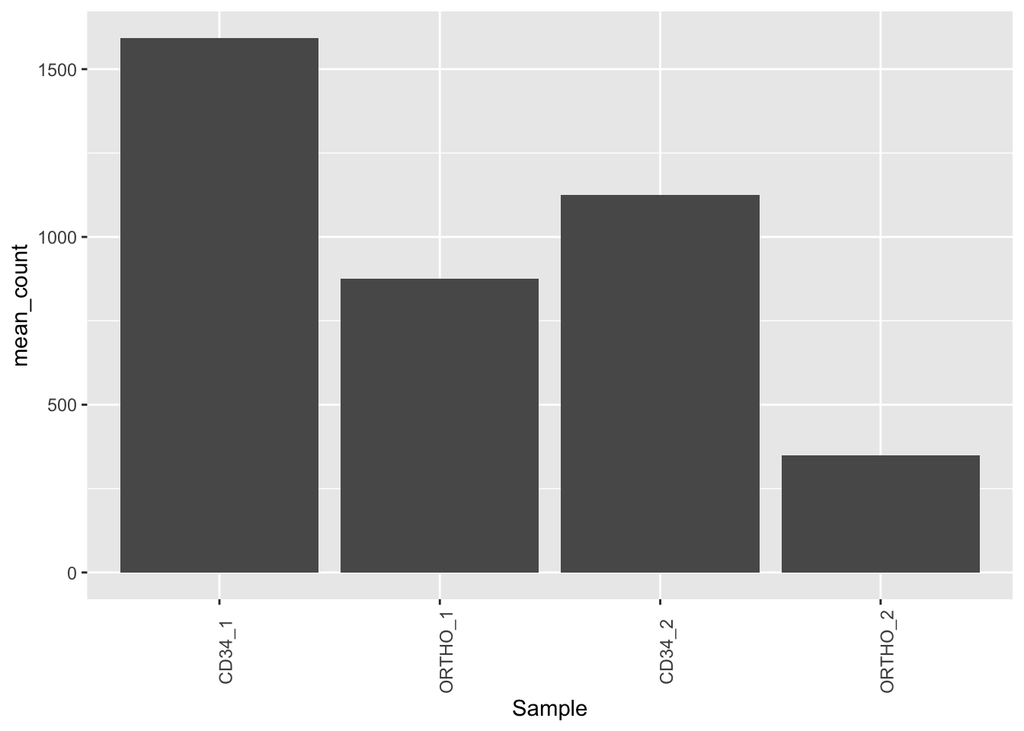

```r
p
```

## forcats::fct_relevel - Reorder manually

```r
# fct_relevel - reorder manually
tidy_counts_expressed_norm %>%
  ungroup() %>%
  mutate_at(vars(Sample), as_factor) %>%
  mutate(Sample = fct_relevel(Sample, my_levels1)) %>%
  pull(Sample) %>% head(n=10)
```

```
##  [1] CD34_1  ORTHO_1 CD34_2  ORTHO_2 CD34_1  ORTHO_1 CD34_2  ORTHO_2 CD34_1  ORTHO_1
## Levels: ORTHO_1 ORTHO_2 CD34_1 CD34_2
```

```r
# fct_relevel - reorder manually
tidy_counts_expressed_norm %>%
  ungroup() %>%
  mutate_at(vars(Sample), as_factor) %>%
  mutate(Sample = fct_relevel(Sample, my_levels2)) %>%
  pull(Sample) %>% head(n=10)
```

```
##  [1] CD34_1  ORTHO_1 CD34_2  ORTHO_2 CD34_1  ORTHO_1 CD34_2  ORTHO_2 CD34_1  ORTHO_1
## Levels: ORTHO_1 CD34_1 CD34_2 ORTHO_2
```

## forcats::fct_reorder - Reorder using data

```r
# fct_reorder - reorder based on the data. Here we are ordering based
# on mean counts for each sample.
tidy_counts_expressed_norm %>%
  ungroup() %>%
  mutate_at(vars(Sample), as_factor) %>%
  mutate(Sample = fct_reorder(Sample, counts, mean)) %>%
  pull(Sample) %>% head(n=10)
```

```
##  [1] CD34_1  ORTHO_1 CD34_2  ORTHO_2 CD34_1  ORTHO_1 CD34_2  ORTHO_2 CD34_1  ORTHO_1
## Levels: ORTHO_2 ORTHO_1 CD34_2 CD34_1
```

## Now our ordering can be fixed

```r
p <- tidy_counts_expressed_norm %>%
  ungroup() %>%
  mutate_at(vars(Sample), as_factor) %>%
  mutate(Sample=fct_relevel(Sample, my_levels1)) %>%
  group_by(Sample) %>%
  summarize(mean_count=mean(counts)) %>%
  ggplot(aes(x=Sample, y= mean_count)) +
  geom_bar(stat = "identity") +
  theme(axis.text.x = element_text(angle = 90))
```

## Now our ordering can be fixed

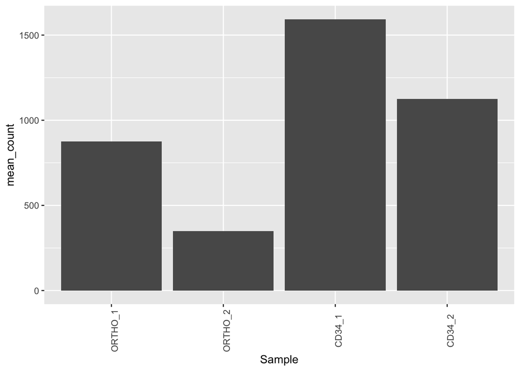

```r
p
```

## forcats::fct_recode - Change levels

```r
df1$age_classbylength
```

```
##  [1] "yearling"           "juvenile"           "juvenile"           "juvenile"
##  [5] "juvenile"           "mixed age juvenile" "juvenile"           "juvenile"
##  [9] "juvenile"           "juvenile"           "juvenile"           "juvenile"
## [13] "juvenile"           "juvenile"           "juvenile"           "juvenile"
## [17] "juvenile"           "juvenile"           "juvenile"           "juvenile"
## [21] "juvenile"           "juvenile"           "juvenile"           "juvenile"
## [25] "juvenile"           "juvenile"           "juvenile"           "juvenile"
## [29] "juvenile"           "juvenile"           "yearling"           "yearling"
## [33] "juvenile"           "yearling"           "mixed age juvenile" "juvenile"
## [37] "juvenile"           "juvenile"           "juvenile"           "juvenile"
## [41] "juvenile"           "juvenile"           "yearling"           "yearling"
## [45] "yearling"           "yearling"           "yearling"           "yearling"
## [49] "yearling"           "yearling"           "yearling"           "yearling"
## [53] "yearling"           "yearling"           "yearling"           "yearling"
## [57] "yearling"           "yearling"           "subyearling"        "juvenile"
## [61] "juvenile"           "juvenile"           "juvenile"           "juvenile"
## [65] "juvenile"           "yearling"           "juvenile"           "juvenile"
## [69] "mixed age juvenile" "yearling"           "yearling"           "yearling"
## [73] "yearling"           "yearling"           "yearling"           "yearling"
## [77] "yearling"           "juvenile"           "juvenile"           "juvenile"
## [81] "juvenile"           "juvenile"           "yearling"           "yearling"
## [85] "yearling"           "yearling"           "yearling"           "yearling"
## [89] "yearling"           "yearling"           "yearling"           "yearling"
## [93] "yearling"           "yearling"           "yearling"           "yearling"
## [97] "yearling"
```

```r
# Recoding levels to give them a new name
df1 %>%
  mutate_at(vars(age_classbylength), as_factor) %>%
  mutate(age_classbylength=fct_recode(age_classbylength, "mixed juvenile" = "mixed age juvenile")) %>%
  pull(age_classbylength)
```

```
##  [1] yearling       juvenile       juvenile       juvenile       juvenile       mixed juvenile
##  [7] juvenile       juvenile       juvenile       juvenile       juvenile       juvenile
## [13] juvenile       juvenile       juvenile       juvenile       juvenile       juvenile
## [19] juvenile       juvenile       juvenile       juvenile       juvenile       juvenile
## [25] juvenile       juvenile       juvenile       juvenile       juvenile       juvenile
## [31] yearling       yearling       juvenile       yearling       mixed juvenile juvenile
## [37] juvenile       juvenile       juvenile       juvenile       juvenile       juvenile
## [43] yearling       yearling       yearling       yearling       yearling       yearling
## [49] yearling       yearling       yearling       yearling       yearling       yearling
## [55] yearling       yearling       yearling       yearling       subyearling    juvenile
## [61] juvenile       juvenile       juvenile       juvenile       juvenile       yearling
## [67] juvenile       juvenile       mixed juvenile yearling       yearling       yearling
## [73] yearling       yearling       yearling       yearling       yearling       juvenile
## [79] juvenile       juvenile       juvenile       juvenile       yearling       yearling
## [85] yearling       yearling       yearling       yearling       yearling       yearling
## [91] yearling       yearling       yearling       yearling       yearling       yearling
## [97] yearling
## Levels: yearling juvenile mixed juvenile subyearling
```

```r
# Recoding levels to change to add one factor to another factor
df1 %>%
  mutate_at(vars(age_classbylength), as_factor) %>%
  mutate(age_classbylength=fct_recode(age_classbylength, "juvenile" = "mixed age juvenile")) %>%
  pull(age_classbylength)
```

```
##  [1] yearling    juvenile    juvenile    juvenile    juvenile    juvenile    juvenile    juvenile
##  [9] juvenile    juvenile    juvenile    juvenile    juvenile    juvenile    juvenile    juvenile
## [17] juvenile    juvenile    juvenile    juvenile    juvenile    juvenile    juvenile    juvenile
## [25] juvenile    juvenile    juvenile    juvenile    juvenile    juvenile    yearling    yearling
## [33] juvenile    yearling    juvenile    juvenile    juvenile    juvenile    juvenile    juvenile
## [41] juvenile    juvenile    yearling    yearling    yearling    yearling    yearling    yearling
## [49] yearling    yearling    yearling    yearling    yearling    yearling    yearling    yearling
## [57] yearling    yearling    subyearling juvenile    juvenile    juvenile    juvenile    juvenile
## [65] juvenile    yearling    juvenile    juvenile    juvenile    yearling    yearling    yearling
## [73] yearling    yearling    yearling    yearling    yearling    juvenile    juvenile    juvenile
## [81] juvenile    juvenile    yearling    yearling    yearling    yearling    yearling    yearling
## [89] yearling    yearling    yearling    yearling    yearling    yearling    yearling    yearling
## [97] yearling
## Levels: yearling juvenile subyearling
```